# The effects of body tissue and gene drift on the differential gene expression of Aphedius ervi

Nanda Vo

documentation of packages for analyses

https://myles-lewis.github.io/glmmSeq/articles/glmmSeq.html#citing-glmmseq https://bioconductor.org/packages/devel/bioc/vignettes/DESeq2/inst/doc/DESeq2.html

# Introduction

This markdown file serves as workflow for the differential gene expression analysis on Aphedius ervi. In this thesis, I study two families of A. ervi, that were separately inbreded beforehand, to achieve genetic homogenity.

The dataset consists of three treatment compartemnts: Line, Conditioned, and Experience. Line describes the lineage of the subjects. All parental generations were exclusively reared on the same type of host, PA (pea aphid) or FA (foxglove aphid). Conditioned describes the type of host, where the subjects emerged from. Experience describes the type of host, that was forced on the subject for ovipositioning.

In this thesis, I aim to study the relative contributions of the treatments (treatment components) on the differential gene expression of the studied individuals.

## Load needed libraries

```r
# Load necessary libraries
library(pvclust)
library(glmmSeq)
library(MASS)
library(car)
library(ggplot2)
library(ggpubr)
library(lme4)
library(lmerTest)
library(qvalue)
library(limma)
library(edgeR)
library(knitr)
library(kableExtra)
library(qvalue)
library(lmerTest)
library(glmmSeq)
library(DESeq2)
library(plyr)
library(dplyr)
library(DESeq2)
library(edgeR)
library(pheatmap)
library(RColorBrewer)
library(parallel)
library(ggpubr)  # For adding p-values to plots
library(ComplexHeatmap)
library(circlize)
library(kableExtra)
library(VennDiagram)

# Set knitr root directory for knitting
knitr::opts_knit$set(root.dir = "C:/Users/nanda/Desktop/Master Thesis")
```

## Load the pre-processed count and sample tables into R.

```r
setwd("C:/Users/nanda/Desktop/Master Thesis")
# Load count data
counts_data <- read.csv("counts.csv")
# Set gene column as row names
rownames(counts_data) <- counts_data$Gene
# Remove Gene as a column
counts_data$Gene <- NULL

# Load sample data
samples_data <- read.csv("samples.csv")
# Set Sample column as row names
rownames(samples_data) <- samples_data$Sample
# Remove Sample as a column
samples_data$Sample <- NULL
# Normalize Treatment column
samples_data$Treatment <- gsub("-", "_", samples_data$Treatment)

# Filter out samples where 'Line' contains "G(FA)"
samples_data <- samples_data %>%
  filter(!grepl("G\\(FA\\)", Line))

# Ensure counts_data has columns that match filtered samples_data rows
counts_data <- counts_data[, colnames(counts_data) %in% rownames(samples_data)]

# Double check matching rows and columns of samples and counts
if (!all(colnames(counts_data) %in% rownames(samples_data))) {
  stop("Mismatch between samples and counts data.")
}
if (!all(colnames(counts_data) == rownames(samples_data))) {
  stop("Order of samples and counts data do not match.")
}
```

## Filter data by CPM

Now, we filter or count data by removing genes with a CPM (counts per million) below 1, using edgeR. Out of 20226 genes, we removed 1881.

```r
# Create a DGEList object for edgeR
dge <- DGEList(counts = counts_data)

# Calculate CPM
cpm_data <- cpm(dge)

# Define a filter threshold (1 CPM)
cpm_threshold <- 1
keep <- rowSums(cpm_data >= cpm_threshold) >= 1
dge <- dge[keep,]
dim(dge)
```

```
## [1] 18345   132
```

```r
# Filter the count data
filtered_counts_data <- counts_data[keep, ]
```

## DESeq2 dds object

DGE analysis with DESeq2 using following model: counts ~ Line + Conditioned + Experience + Tissue + Family. I use DESeq2 to get an overall impression of the differentiality of gene expression profiles. This means that I aim to compare the overall expression profile of the individuals for the beginning.

```r
# Create DESeq2 object
dds <- DESeqDataSetFromMatrix(countData = filtered_counts_data,
                              colData = samples_data,
                              design = ~  Line + Conditioned + Experience + Tissue + Family)

# Perform differential expression analysis
dds <- DESeq(dds)

#save dds object
#saveRDS(dds, file = "dds_model.rds")
  #load it
  #dds <- readRDS("dds_model.rds")
```

## Gene dispersion and normalized counts

Calculate dispersions and normalize counts. The dispersion represents the variability of gene expression levels.

The normalization by size factors corrects for sequencing depths (important for avoiding false negatives for lowly expressed genes)

Also apply variance stabilizing transformation on data

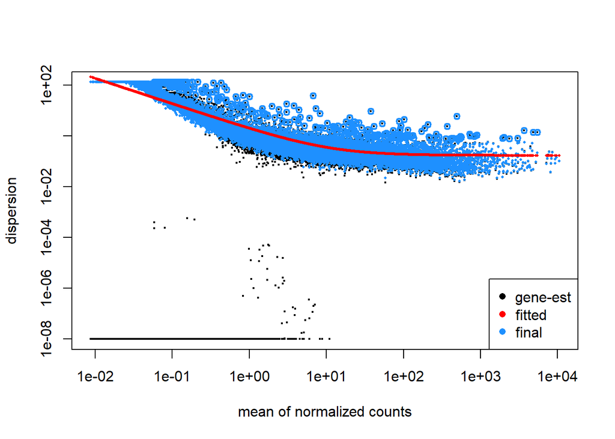

```r
 # Estimate dispersions (this is already done during the DESeq call)
        dds <- estimateDispersions(dds)
## found already estimated dispersions, replacing these
## gene-wise dispersion estimates
## mean-dispersion relationship
## final dispersion estimates
        dispersions <- dispersions(dds)
        dispersions <- setNames(dispersions, rownames(filtered_counts_data))

        # Estimate size factors (this is also done during DESeq normalization)
        dds <- estimateSizeFactors(dds)
        size_factors <- sizeFactors(dds)

        # Normalize counts by size factors
        normalized_counts <- counts(dds, normalized = TRUE)


        # Plot dispersion estimates
        plotDispEsts(dds)


        # Variance stabilizing transformation (VST); DESeq2 usually uses normalized counts for the VST
        vst_dds <- vst(dds)

        # You can use the transformed data for PCA or clustering
        vst_counts <- assay(vst_dds)
```

## PCA by tissue

Do PCA with the top 500 most variable genes. For the beginning, I’m separating by tissue type.

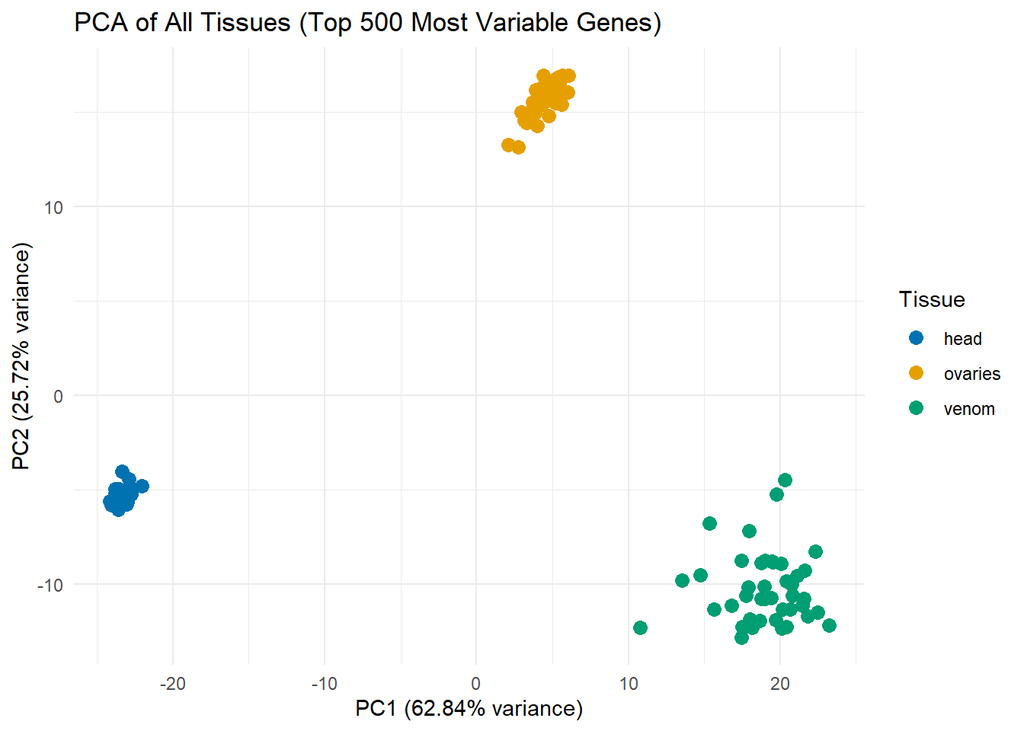

```r
       #PCA plot by tissue
                  # Identify the variance for each gene
      gene_variances <- apply(vst_counts, 1, var)

      # Select the top 500 most variable genes
      top_500_genes <- order(gene_variances, decreasing = TRUE)[1:500]

      # Subset the VST data to include only these top 500 genes
      vst_counts_top_500 <- vst_counts[top_500_genes, ]

      # Perform PCA on the filtered VST data for the top 500 genes
      pca_top_500 <- prcomp(t(vst_counts_top_500), scale. = TRUE)

      # Calculate the percentage of variance explained by PC1 and PC2
      explained_variance <- summary(pca_top_500)$importance[2, ]
      pc1_var <- round(explained_variance[1] * 100, 2)
      pc2_var <- round(explained_variance[2] * 100, 2)

      # Create a data frame with PCA results and sample metadata
      pca_data_top_500 <- as.data.frame(pca_top_500$x)
      pca_data_top_500$Tissue <- samples_data$Tissue

      # Plot PCA with colorblind-friendly colors and variance percentages
      library(ggplot2)
      ggplot(pca_data_top_500, aes(x = PC1, y = PC2, color = Tissue)) +
        geom_point(size = 3) +
        scale_color_manual(values = c("#0072B2", "#E69F00", "#009E73")) + # Blue, Orange, Green
        labs(
          title = "PCA of All Tissues (Top 500 Most Variable Genes)",
          x = paste0("PC1 (", pc1_var, "% variance)"),
          y = paste0("PC2 (", pc2_var, "% variance)")
        ) +
        theme_minimal()
```

## PCA within tissue by family

Since the expression profiles are clearly clustered by tissue (and high percentages for PC 1), I’ll do a PCA within each tissue type, separating by family as well. The separation implies that each tissue type has a distinct group of expressed genes. I’ll also verify it later by creating tables showing the number of overlapping genes between tissue types. (glmmSeq section)

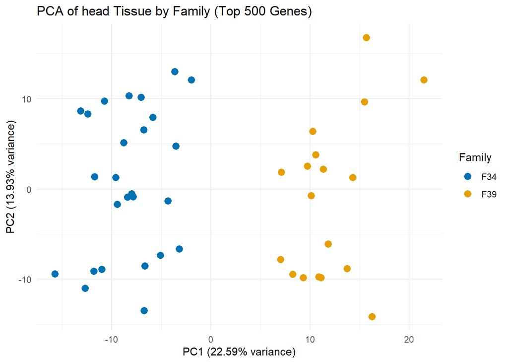

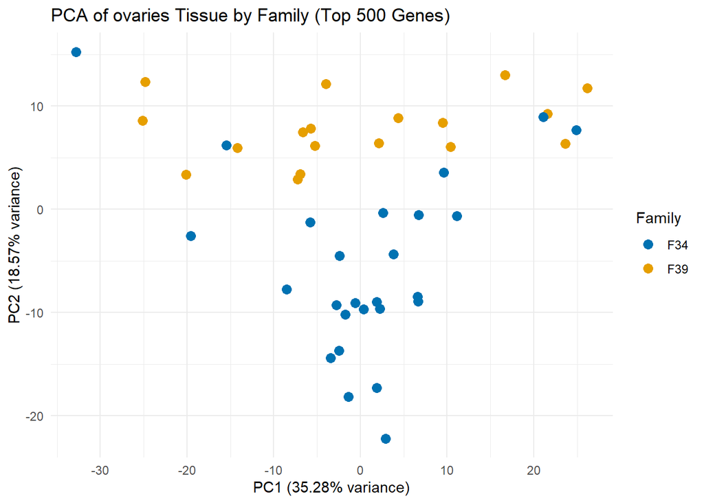

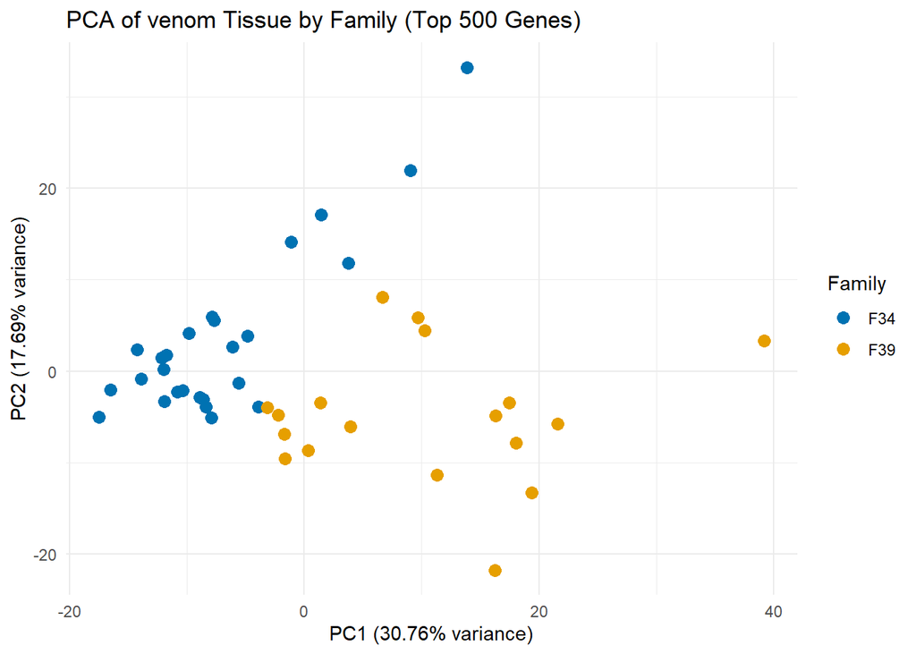

```r
      # PCA plot by family within each tissue for the top 500 most variable genes
      perform_pca <- function(tissue_name, normalized_counts, samples_data) {

      # Subset the samples_data for the specified tissue
      tissue_samples <- samples_data[samples_data$Tissue == tissue_name, ]

      # Subset the normalized counts data for the specified tissue
      tissue_counts <- normalized_counts[, rownames(tissue_samples)]

      # Identify the variance for each gene
      gene_variances <- apply(tissue_counts, 1, var)

      # Select the top 500 most variable genes
      top_500_genes <- order(gene_variances, decreasing = TRUE)[1:500]

      # Subset the data to include only these top 500 genes
      tissue_counts_top_500 <- tissue_counts[top_500_genes, ]

      # Perform PCA on the filtered tissue data for the top 500 genes
      pca_result <- prcomp(t(tissue_counts_top_500), scale. = TRUE)

      # Calculate the percentage of variance explained by PC1 and PC2
      explained_variance <- summary(pca_result)$importance[2, ]
      pc1_var <- round(explained_variance[1] * 100, 2)
      pc2_var <- round(explained_variance[2] * 100, 2)

      # Create a data frame with PCA results and sample metadata
      pca_data <- as.data.frame(pca_result$x)
      pca_data$Family <- tissue_samples$Family

      # Plot PCA with colorblind-friendly colors and variance percentages
      pca_plot <- ggplot(pca_data, aes(x = PC1, y = PC2, color = Family)) +
        geom_point(size = 3) +
        scale_color_manual(values = c("#0072B2", "#E69F00")) + # Blue, Orange
        labs(
          title = paste("PCA of", tissue_name, "Tissue by Family (Top 500 Genes)"),
          x = paste0("PC1 (", pc1_var, "% variance)"),
          y = paste0("PC2 (", pc2_var, "% variance)")
        ) +
        theme_minimal()

      return(pca_plot)
    }

    # Create plots for each tissue
    pca_head_plot <- perform_pca("head", normalized_counts, samples_data)
    pca_ovaries_plot <- perform_pca("ovaries", normalized_counts, samples_data)
    pca_venom_plot <- perform_pca("venom", normalized_counts, samples_data)

    # Display the plots
    print(pca_head_plot)
    print(pca_ovaries_plot)
    print(pca_venom_plot)
```

Head and venom tissues show clear separation between families, mostly represented by PC 1. This implies that the family has the biggest effect on the separation between those two distinct clusters. For the ovaries, the families show two distinct clusters as well, but mostly represented by PC 2. Consequently, there may be another factor that contributes more in the variance of the mean ovary expression profiles (of the top 500 most variable genes) of the samples.

## Volcano plots within tissue by family

The following volcano plots underline these findings.

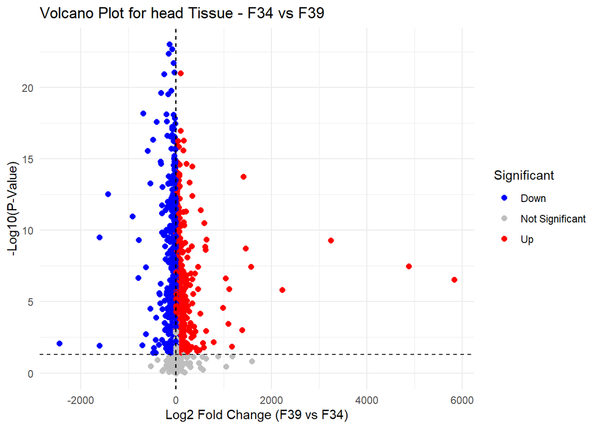

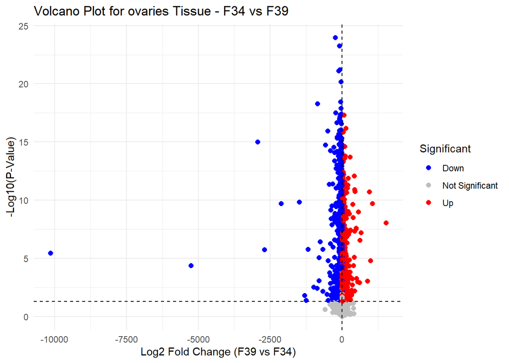

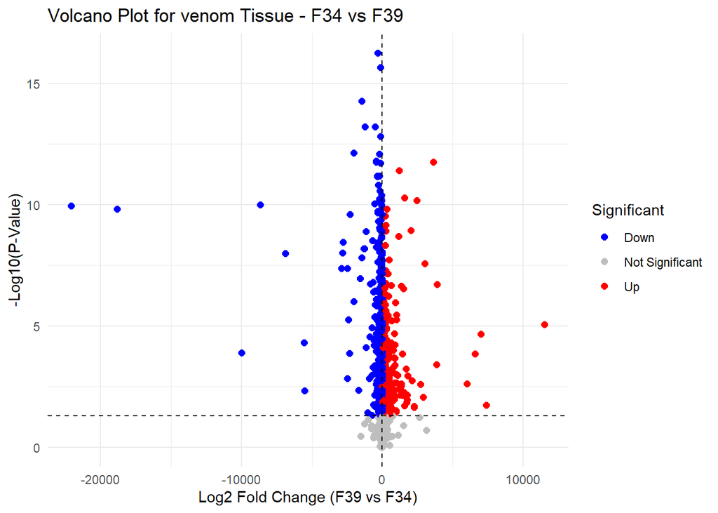

```r
 #volcano plots between families within each treatment
          # Define the volcano plot function for comparing Family F34 vs F39 within a tissue
          perform_volcano_plot_family_comparison <- function(tissue_name, normalized_counts, samples_data) {

            # Subset the samples_data for the specified tissue
            tissue_samples <- samples_data[samples_data$Tissue == tissue_name & samples_data$Family %in% c("F34", "F39"), ]

            # Subset the normalized counts data for the specified tissue
            tissue_counts <- normalized_counts[, rownames(tissue_samples)]

            # Ensure the Family column is recognized as a factor
            tissue_samples$Family <- factor(tissue_samples$Family)

            # Calculate log2 fold changes and p-values between Family F34 and F39
            log2_fc <- apply(tissue_counts, 1, function(gene_counts) {
              mean(gene_counts[tissue_samples$Family == "F39"]) -
                mean(gene_counts[tissue_samples$Family == "F34"])
            })

            # Perform t-tests to get p-values
            p_values <- apply(tissue_counts, 1, function(gene_counts) {
              t.test(gene_counts[tissue_samples$Family == "F34"],
                     gene_counts[tissue_samples$Family == "F39"])$p.value
            })

            # Create a data frame with the results
            results <- data.frame(
              Gene = rownames(tissue_counts),
              log2FC = log2_fc,
              p_value = p_values,
              neg_log10_p_value = -log10(p_values)
            )

            # Filter out rows with NA, Inf, or -Inf values
            results <- results %>%
              filter(!is.na(log2FC) & !is.infinite(log2FC) &
                       !is.na(neg_log10_p_value) & !is.infinite(neg_log10_p_value))

            # Determine significance (adjust as needed, e.g., p < 0.05 and |log2FC| > 1)
            results$Significant <- "Not Significant"
            results$Significant[results$p_value < 0.05 & results$log2FC > 1] <- "Up"
            results$Significant[results$p_value < 0.05 & results$log2FC < -1] <- "Down"

            # Create the volcano plot comparing F34 vs F39
            volcano_plot <- ggplot(results, aes(x = log2FC, y = neg_log10_p_value, color = Significant)) +
              geom_point(size = 2) +
              scale_color_manual(values = c("Not Significant" = "gray", "Up" = "red", "Down" = "blue")) +
              labs(title = paste("Volcano Plot for", tissue_name, "Tissue - F34 vs F39"),
                   x = "Log2 Fold Change (F39 vs F34)",
                   y = "-Log10(P-Value)") +
              geom_vline(xintercept = c(-1, 1), linetype = "dashed") +  # Add vertical lines at log2FC = ±1
              geom_hline(yintercept = -log10(0.05), linetype = "dashed") +  # Add horizontal line at p = 0.05
              theme_minimal()

            return(volcano_plot)
          }

          # Example usage for all tissues
          volcano_head_plot <- perform_volcano_plot_family_comparison("head", normalized_counts, samples_data)
          volcano_ovaries_plot <- perform_volcano_plot_family_comparison("ovaries", normalized_counts, samples_data)
          volcano_venom_plot <- perform_volcano_plot_family_comparison("venom", normalized_counts, samples_data)

          # Display the plots for F34 vs F39 in each tissue
          print(volcano_head_plot)  # Volcano plot for head tissue (F34 vs F39)
          print(volcano_ovaries_plot)  # Volcano plot for ovaries tissue (F34 vs F39)
          print(volcano_venom_plot)  # Volcano plot for venom tissue (F34 vs F39)
```

The majority of the individuals genes show a clear up- (positive LFC) or downregulation (negative LFC).

## Heatmaps for treatment similarity

I’m proceeding to heatmaps to show comparison between treatment similarity. The heatmaps are calculated by comparing the Euclidean distance between the expression profiles of each unique sample (Family + Treatments + Tissue).

The data was log transformed to stabilize the variance and reduce the influence of highly expressed genes. We’re also using the top 500 most variable genes again.

All heatmaps are too small on the html file, so I’ll send them to you separately.

[figure not shown]

```r
# Corrected combination of treatments for filtering
required_combinations <- c(
  "PA_PA_PA", "PA_PA_FA", "PA_FA_PA", "PA_FA_FA",
  "FA_FA_FA", "FA_PA_PA", "FA_PA_FA", "FA_FA_PA"
)

# Filter samples to include all required treatment combinations
filtered_samples <- samples_data %>% filter(
  Treatment %in% required_combinations
)

# Create descriptive sample names including Treatment, Family, and Tissue
filtered_samples$DescriptiveLabel <- paste(filtered_samples$Treatment, filtered_samples$Family, filtered_samples$Tissue, sep = "_")

# Ensure unique descriptive labels
filtered_samples <- filtered_samples %>% distinct(DescriptiveLabel, .keep_all = TRUE)

# Ensure the filtered count data matches the filtered samples
filtered_counts <- counts_data[, colnames(counts_data) %in% rownames(filtered_samples)]

# Ensure filtered_counts has the same order as filtered_samples
filtered_counts <- filtered_counts[, rownames(filtered_samples)]

# Verify that the number of samples matches
if (ncol(filtered_counts) != nrow(filtered_samples)) {
  stop("Mismatch in number of samples between filtered counts and filtered samples!")
}

# Check for duplicates in descriptive labels
if (any(duplicated(filtered_samples$DescriptiveLabel))) {
  stop("Duplicate sample labels found!")
}

# Apply log transformation to stabilize variance and reduce scale
log_filtered_counts <- log1p(filtered_counts)  # log1p(x) = log(1 + x)

# Identify the top 500 most variable genes across all samples
gene_variances <- apply(log_filtered_counts, 1, var)
top_500_genes <- order(gene_variances, decreasing = TRUE)[1:500]
log_filtered_counts_top_500 <- log_filtered_counts[top_500_genes, ]

# Calculate the distance matrix using only the top 500 most variable genes
dist_matrix <- dist(t(log_filtered_counts_top_500), method = "euclidean")
dist_matrix <- as.matrix(dist_matrix)

# Define colors for the heatmap
colors <- colorRampPalette(rev(brewer.pal(9, "Blues")))(255)

# Create heatmap with proper labels using the distance matrix
pheatmap(
  dist_matrix,
  cluster_rows = hclust(as.dist(dist_matrix)),
  cluster_cols = hclust(as.dist(dist_matrix)),
  labels_row = filtered_samples$DescriptiveLabel,
  labels_col = filtered_samples$DescriptiveLabel,
  col = colors,
  main = "Heatmap of Treatment-Family-Tissue Similarities (Top 500 Most Variable Genes)",
  display_numbers = TRUE
)
```

## Overall heatmap with bootstrap

I’m repeating the heatmaps with a bootstrapping methid: 30.000 iterations for resampling The bootstrapping allows for resampling between the top 500 most variable genes with some genes being selected more than once in each iteration.

[figure not shown]

```r
# Define the required treatment combinations
required_combinations <- c(
  "PA_PA_PA", "PA_PA_FA", "PA_FA_PA", "PA_FA_FA",
  "FA_FA_FA", "FA_PA_PA", "FA_PA_FA", "FA_FA_PA"
)

# Filter samples to include all required treatment combinations
filtered_samples <- samples_data %>% filter(
  Treatment %in% required_combinations
)

# Create descriptive sample names including Treatment, Family, and Tissue
filtered_samples$DescriptiveLabel <- paste(filtered_samples$Treatment, filtered_samples$Family, filtered_samples$Tissue, sep = "_")

# Ensure unique descriptive labels
filtered_samples <- filtered_samples %>% distinct(DescriptiveLabel, .keep_all = TRUE)

# Ensure the filtered count data matches the filtered samples
filtered_counts <- counts_data[, colnames(counts_data) %in% rownames(filtered_samples)]

# Ensure filtered_counts has the same order as filtered_samples
filtered_counts <- filtered_counts[, rownames(filtered_samples)]

# Verify that the number of samples matches
if (ncol(filtered_counts) != nrow(filtered_samples)) {
  stop("Mismatch in number of samples between filtered counts and filtered samples!")
}

# Check for duplicates in descriptive labels
if (any(duplicated(filtered_samples$DescriptiveLabel))) {
  stop("Duplicate sample labels found!")
}

# Apply log transformation to stabilize variance and reduce scale
log_filtered_counts <- log1p(filtered_counts)  # log1p(x) = log(1 + x)

# Identify the top 500 most variable genes across all samples
gene_variances <- apply(log_filtered_counts, 1, var)
top_500_genes <- order(gene_variances, decreasing = TRUE)[1:500]
log_filtered_counts_top_500 <- log_filtered_counts[top_500_genes, ]

# Set parameters for bootstrapping
n_bootstrap <- 30000  # Number of bootstrap iterations
n_genes <- nrow(log_filtered_counts_top_500)  # Set to 500 most variable genes
bootstrap_dist_matrices <- array(0, dim = c(ncol(log_filtered_counts_top_500), ncol(log_filtered_counts_top_500), n_bootstrap))

# Bootstrapping loop
for (i in 1:n_bootstrap) {
  # Resample top 500 most variable genes with replacement
  resampled_genes <- sample(1:n_genes, size = 500, replace = TRUE)
  resampled_counts <- log_filtered_counts_top_500[resampled_genes, ]

  # Calculate the distance matrix using the resampled genes
  dist_matrix <- dist(t(resampled_counts), method = "euclidean")
  bootstrap_dist_matrices[, , i] <- as.matrix(dist_matrix)
}

# Average the distance matrix over all bootstrap samples
avg_dist_matrix <- apply(bootstrap_dist_matrices, c(1, 2), mean)

# Define a contrasting color palette that has dark colors for low values and bright colors for high values
colors <- colorRamp2(c(0, max(avg_dist_matrix) * 0.5, max(avg_dist_matrix)), c("darkblue", "skyblue", "white"))

# Create heatmap with ComplexHeatmap using the improved and reversed color scale
Heatmap(
  avg_dist_matrix,
  name = "Log-Transformed Euclidean Distances",  # Explicitly set the legend title
  col = colors,
  cluster_rows = TRUE,
  cluster_columns = TRUE,
  row_labels = filtered_samples$DescriptiveLabel,
  column_labels = filtered_samples$DescriptiveLabel,
  cell_fun = function(j, i, x, y, width, height, fill) {
    # Set text color to black or white depending on background brightness for visibility
    text_color <- ifelse(avg_dist_matrix[i, j] > (max(avg_dist_matrix) * 0.4), "black", "white")
    grid.text(sprintf("%.1f", avg_dist_matrix[i, j]), x, y, gp = gpar(fontsize = 6, col = text_color))
  },
  heatmap_legend_param = list(
    title = "Log-Transformed Euclidean Distances",
    at = seq(0, max(avg_dist_matrix), by = 20),  # Adjust legend scale to reflect full data range
    labels = seq(0, max(avg_dist_matrix), by = 20)
  ),
  column_title = "Bootstrap Averaged Heatmap\n(Top 500 Most Variable Genes Across All Tissues)"  # Set the main title
)
```

## Heatmap for each tissue with bootstrap

Heatmap (with 30.000 bootstraps) within each tissue:

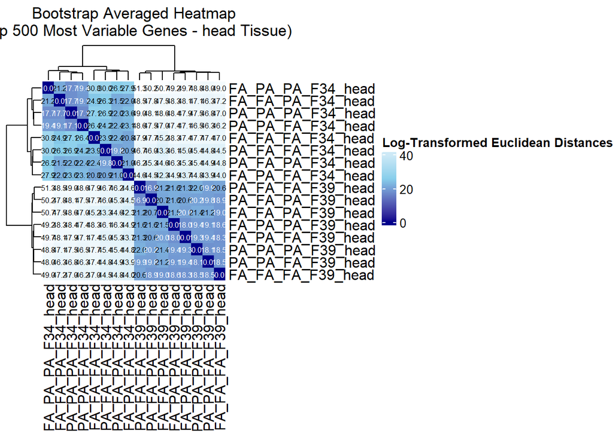

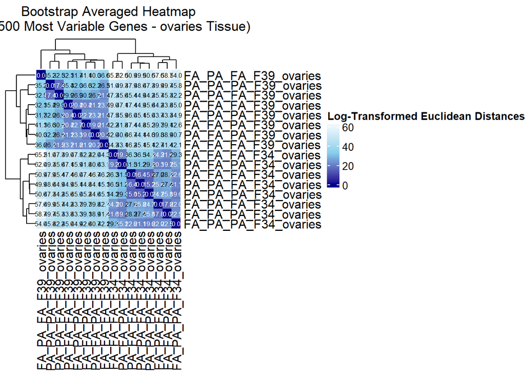

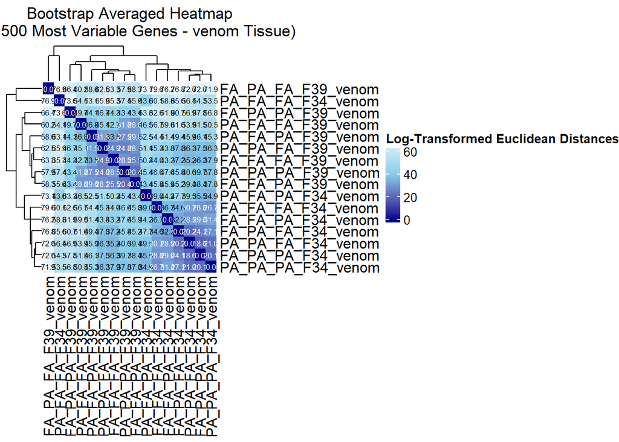

```r
# Define the required treatment combinations
required_combinations <- c(
  "PA_PA_PA", "PA_PA_FA", "PA_FA_PA", "PA_FA_FA",
  "FA_FA_FA", "FA_PA_PA", "FA_PA_FA", "FA_FA_PA"
)

# List of unique tissues
tissues <- unique(samples_data$Tissue)

# Loop through each tissue type to generate heatmaps
for (tissue in tissues) {
  print(paste("Generating heatmap for tissue:", tissue))

  # Filter samples for the specific tissue type
  filtered_samples <- samples_data %>%
    filter(Treatment %in% required_combinations & Tissue == tissue)

  # Create descriptive sample names including Treatment, Family, and Tissue
  filtered_samples$DescriptiveLabel <- paste(filtered_samples$Treatment, filtered_samples$Family, filtered_samples$Tissue, sep = "_")

  # Ensure unique descriptive labels
  filtered_samples <- filtered_samples %>% distinct(DescriptiveLabel, .keep_all = TRUE)

  # Ensure the filtered count data matches the filtered samples
  filtered_counts <- counts_data[, colnames(counts_data) %in% rownames(filtered_samples)]

  # Ensure filtered_counts has the same order as filtered_samples
  filtered_counts <- filtered_counts[, rownames(filtered_samples)]

  # Verify that the number of samples matches
  if (ncol(filtered_counts) != nrow(filtered_samples)) {
    stop(paste("Mismatch in number of samples between filtered counts and filtered samples for tissue:", tissue))
  }

  # Check for duplicates in descriptive labels
  if (any(duplicated(filtered_samples$DescriptiveLabel))) {
    stop("Duplicate sample labels found!")
  }

  # Apply log transformation to stabilize variance and reduce scale
  log_filtered_counts <- log1p(filtered_counts)  # log1p(x) = log(1 + x)

  # Identify the top 500 most variable genes across all samples
  gene_variances <- apply(log_filtered_counts, 1, var)
  top_500_genes <- order(gene_variances, decreasing = TRUE)[1:500]
  log_filtered_counts_top_500 <- log_filtered_counts[top_500_genes, ]

  # Set parameters for bootstrapping
  n_bootstrap <- 30000  # Number of bootstrap iterations
  n_genes <- nrow(log_filtered_counts_top_500)  # Set to 500 most variable genes
  bootstrap_dist_matrices <- array(0, dim = c(ncol(log_filtered_counts_top_500), ncol(log_filtered_counts_top_500), n_bootstrap))

  # Bootstrapping loop
  for (i in 1:n_bootstrap) {
    # Resample top 500 most variable genes with replacement
    resampled_genes <- sample(1:n_genes, size = 500, replace = TRUE)
    resampled_counts <- log_filtered_counts_top_500[resampled_genes, ]

    # Calculate the distance matrix using the resampled genes
    dist_matrix <- dist(t(resampled_counts), method = "euclidean")
    bootstrap_dist_matrices[, , i] <- as.matrix(dist_matrix)
  }

  # Average the distance matrix over all bootstrap samples
  avg_dist_matrix <- apply(bootstrap_dist_matrices, c(1, 2), mean)

  # Define a contrasting color palette that has dark colors for low values and bright colors for high values
  colors <- colorRamp2(c(0, max(avg_dist_matrix) * 0.5, max(avg_dist_matrix)), c("darkblue", "skyblue", "white"))

  # Create heatmap with ComplexHeatmap using the improved and reversed color scale
  print(Heatmap(
    avg_dist_matrix,
    name = paste("Log-Transformed Euclidean Distances -", tissue),
    col = colors,
    cluster_rows = TRUE,
    cluster_columns = TRUE,
    row_labels = filtered_samples$DescriptiveLabel,
    column_labels = filtered_samples$DescriptiveLabel,
    cell_fun = function(j, i, x, y, width, height, fill) {
      # Set text color to black or white depending on background brightness for visibility
      text_color <- ifelse(avg_dist_matrix[i, j] > (max(avg_dist_matrix) * 0.4), "black", "white")
      grid.text(sprintf("%.1f", avg_dist_matrix[i, j]), x, y, gp = gpar(fontsize = 6, col = text_color))
    },
    heatmap_legend_param = list(
      title = "Log-Transformed Euclidean Distances",
      at = seq(0, max(avg_dist_matrix), by = 20),  # Adjust legend scale to reflect full data range
      labels = seq(0, max(avg_dist_matrix), by = 20)
    ),
    column_title = paste("Bootstrap Averaged Heatmap\n(Top 500 Most Variable Genes -", tissue, "Tissue)")
  ))
}
## [1] "Generating heatmap for tissue: head"
## [1] "Generating heatmap for tissue: ovaries"
## [1] "Generating heatmap for tissue: venom"
```

For both, head and ovaries, the results of the bootstrapped euclidean distance heatmaps show distinct clusters between both families. For venom glands, there is one outlier (PA-FA-FA-F34), which is clustered with the other samples of family F39. My assumption is that the model may have overfitted between small insignificant difference due to the low sample size for every treatment. This observation occurs on a larger scale on the heatmap including all three tissue types.

## GLMMs for each tissue

### GLMM for head

Finally, I’ll proceed with GLMMs to identify sets of significantly differentially expressed genes. Due to the high differentiality caused by the families (PCA plots within each tissue and by family), My GLMMs will incorporate the family as random effect. By doing so, I aim to identify sets of genes, that are reliably differentially expressed in both families.

All models use following design: ~ Line + Conditioned + Experience + (1 | Family) I’ll use DESeq2 to acquire subsetted processed count data first

Following chunk filters the data and runs the GLMM for head tissue.

```r
# Subset the data for head tissue
#model for head
      # Subset the data for head tissue
      head_samples_data <- samples_data[samples_data$Tissue == "head", ]
      head_counts_data <- filtered_counts_data[, rownames(head_samples_data)]

      # Create DESeq2 object for head tissue
      dds_head <- DESeqDataSetFromMatrix(countData = head_counts_data,
                                        colData = head_samples_data,
                                        design = ~ Line + Conditioned + Experience + Family)

      # Perform DESeq normalization and dispersion estimation for head tissue
      dds_head <- DESeq(dds_head)
      dispersions_head <- dispersions(dds_head)
      dispersions_head <- setNames(dispersions_head, rownames(head_counts_data))
      size_factors_head <- sizeFactors(dds_head)

      # Normalize counts by size factors
      normalized_counts_head <- sweep(head_counts_data, 2, size_factors_head, "/")

      # Fit the glmmSeq model for head tissue
      #fit_head <- glmmSeq(~ Line + Conditioned + Experience + (1 | Family),
      #                    countdata = normalized_counts_head,
       #                   metadata = head_samples_data,
        #                  dispersion = dispersions_head,
         #                 family = "nbinom",
          #                progress = TRUE)

      # Save and print results for head tissue
      #saveRDS(fit_head, file = "fit_head_norm.rds")
      fit_head <- readRDS("fit_head_norm.rds")
          #fit_head <- readRDS("fit_head.rds") #alternatively to the counts normalized by size factors

      results_head <- summary(fit_head)
      #print(results_head)

      # Save the q-value results for head tissue
      qval_results_head <- glmmQvals(fit_head)
##
## Line
## ----
## Not Significant     Significant
##           17472             186
##
## Conditioned
## -----------
## Not Significant     Significant
##           16754             904
##
## Experience
## ----------
## Not Significant     Significant
##           17620              38
```

#### Model choice - Head

I’ll also check other possible models (with interaction terms) and compare AIC scores in order to pick the best fitting model.

```r
# Fit the remaining glmmSeq models for head tissue
#head2 <- glmmSeq(~ Line + Conditioned * Experience + (1 | Family),
 #                countdata = normalized_counts_head,
  #               metadata = head_samples_data,
   #              dispersion = dispersions_head,
    #             family = "nbinom",
     #            progress = TRUE)


#head3 <- glmmSeq(~ Line * Conditioned * Experience + (1 | Family),
 #                countdata = normalized_counts_head,
  #               metadata = head_samples_data,
   #              dispersion = dispersions_head,
    #             family = "nbinom",
     #            progress = TRUE)



#head4 <- glmmSeq(~ Line * Conditioned + Experience + (1 | Family),
 #                countdata = normalized_counts_head,
  #               metadata = head_samples_data,
   #              dispersion = dispersions_head,
    #             family = "nbinom",
     #            progress = TRUE)



# Load your GLMM models (assuming they are saved as .RDS files in your working directory)

head1 <- readRDS("fit_head_norm.rds")
head2 <- readRDS("C:/Users/nanda/Desktop/Master Thesis/head2_glmmSeq.rds")
head3 <- readRDS("C:/Users/nanda/Desktop/Master Thesis/head3_glmmSeq.rds")
head4 <- readRDS("C:/Users/nanda/Desktop/Master Thesis/head4_glmmSeq.rds")

# Define a function to extract the correct AIC for GlmmSeq objects
extract_AIC_glmmSeq <- function(glmm_model) {
  # Access the statistics from the stats slot
  stats <- glmm_model@stats$res

  # Extract the AIC value directly from the stats if available
  if ("AIC" %in% colnames(stats)) {
    total_AIC <- sum(stats[, "AIC"], na.rm = TRUE)
  } else {
    # If AIC is not directly available, calculate it using log-likelihood
    logLik_values <- stats[, "logLik"]
    num_params <- ncol(glmm_model@stats$coef) + 1  # fixed effects + dispersion
    total_logLik <- sum(logLik_values, na.rm = TRUE)
    total_AIC <- -2 * total_logLik + 2 * num_params
  }

  return(total_AIC)
}

# Calculate AIC for each model using the correct method
AIC_head1 <- extract_AIC_glmmSeq(head1)
AIC_head2 <- extract_AIC_glmmSeq(head2)
AIC_head3 <- extract_AIC_glmmSeq(head3)
AIC_head4 <- extract_AIC_glmmSeq(head4)

# Print the AIC values
cat("AIC for head1:", AIC_head1, "\n")
## AIC for head1: 5067820
cat("AIC for head2:", AIC_head2, "\n")
## AIC for head2: 5094355
cat("AIC for head3:", AIC_head3, "\n")
## AIC for head3: 5157217
cat("AIC for head4:", AIC_head4, "\n")
## AIC for head4: 5084704
```

The initial model without interaction terms between the coefficients imply that every sub-treatment (line, conditioned, experience) operated independently from each other. For instance, Line can create evolutionary adaptations with fixed and robust expression patterns. The lack of interaction terms implies that plastic responses to emerging from a specific host type does not interact with traits that were potentially fixed over the generations of the line sub-treatment. This also applies to the unique single occasion of ovipositioning, which represents the experience sub-treatment. The same pattern also applies to ovaries and venom glands.

#### Relative contributions of each sub-treatment to the differential gene expression - Head

Plot the significant genes in barplots, also create tables for relative contributions of treatment components with proportion of significant genes (not p-value!).

```r
#barplots for significant genes
     # Define a significance threshold
     q_threshold <- 0.05

    # Extract the number of significant genes for each factor
    num_significant_genes <- c(
    Line = sum(qval_results_head@stats$qvals[, "Line"] < q_threshold),
    Conditioned = sum(qval_results_head@stats$qvals[, "Conditioned"] < q_threshold),
    Experience = sum(qval_results_head@stats$qvals[, "Experience"] < q_threshold))

                  # Convert to data frame for plotting
                  significant_genes_df <- as.data.frame(num_significant_genes)
                  significant_genes_df$Factor <- rownames(significant_genes_df)
                  colnames(significant_genes_df) <- c("Count", "Factor")

                  # Create the bar plot using ggplot2
                  library(ggplot2)
                  ggplot(significant_genes_df, aes(x = Factor, y = Count, fill = Factor)) +
                    geom_bar(stat = "identity") +
                    scale_fill_manual(values = c("#0072B2", "#E69F00", "#009E73")) +  # Colors: Blue, Orange, Green
                    labs(title = "Number of Significant Genes by Factor",
                         x = "Factor",
                         y = "Number of Significant Genes") +
                    theme_minimal()



#table + plots for coefficient of each factor + venn plots of overlapping genes
      # Extract coefficients and p-values for each factor by using correct indexing
      line_coefs <- results_head[, "LinePA"]
      conditioned_coefs <- results_head[, "ConditionedPA"]
      experience_coefs <- results_head[, "ExperiencePA"]

      line_pvals <- results_head[, "P_Line"]
      conditioned_pvals <- results_head[, "P_Conditioned"]
      experience_pvals <- results_head[, "P_Experience"]

      # Calculate summary statistics for each factor
      summary_stats <- data.frame(
        Factor = c("Line", "Conditioned", "Experience"),
        Mean_Coefficient = c(mean(line_coefs, na.rm = TRUE),
                             mean(conditioned_coefs, na.rm = TRUE),
                             mean(experience_coefs, na.rm = TRUE)),
        Median_Coefficient = c(median(line_coefs, na.rm = TRUE),
                               median(conditioned_coefs, na.rm = TRUE),
                               median(experience_coefs, na.rm = TRUE)),
        Proportion_Significant = c(mean(line_pvals < 0.05, na.rm = TRUE),
                                   mean(conditioned_pvals < 0.05, na.rm = TRUE),
                                   mean(experience_pvals < 0.05, na.rm = TRUE))
      )

      # Print summary statistics
      print(summary_stats)
##        Factor Mean_Coefficient Median_Coefficient Proportion_Significant
## 1        Line      0.004485506        0.004369112             0.07866123
## 2 Conditioned      0.056749456        0.032620523             0.14684562
## 3  Experience      0.011006724       -0.004474694             0.02135010


      # Update the column names of summary_stats for better readability
      colnames(summary_stats) <- c("Factor", "Mean Coefficient", "Median Coefficient", "Proportion Significant")

      # Display the summary statistics using kable with updated column names
      kable(summary_stats, caption = "Summary of Factor Effects on Gene Expression") %>%
        kable_styling(bootstrap_options = c("striped", "hover", "condensed"), full_width = F)
```

Summary of Factor Effects on Gene Expression

| Factor | Mean Coefficient | Median Coefficient | Proportion Significant |
| --- | --- | --- | --- |
| Line | 0.0044855 | 0.0043691 | 0.0786612 |
| Conditioned | 0.0567495 | 0.0326205 | 0.1468456 |
| Experience | 0.0110067 | -0.0044747 | 0.0213501 |

Number of Overlapping Genes Between Line, Conditioned, and Experience (Head)

| Comparison | Overlapping_Genes |
| --- | --- |
| Line vs Conditioned | 72 |
| Line vs Experience | 34 |
| Conditioned vs Experience | 35 |
| Line vs Conditioned vs Experience | 31 |

[figure not shown]

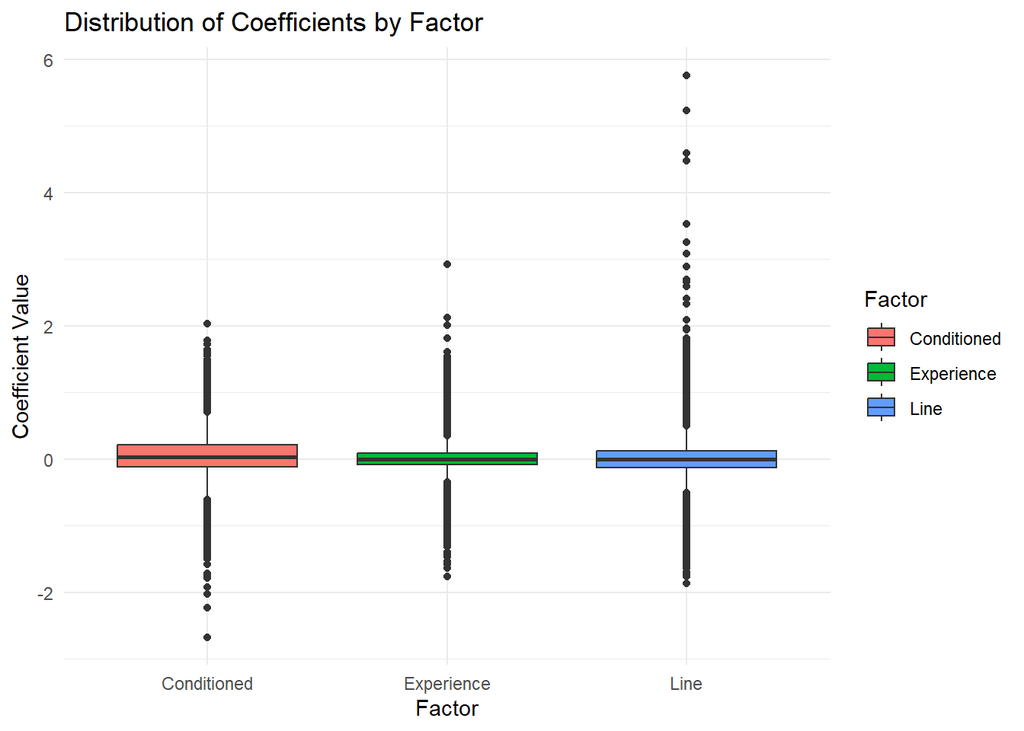

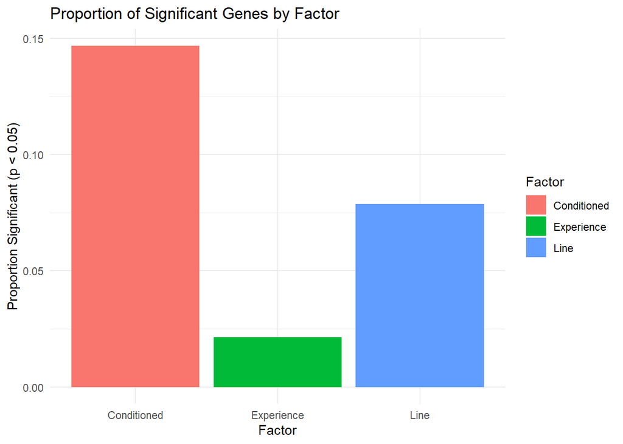

```r
        # Combine data into a long format for plotting
      coefficients_df <- data.frame(
        Factor = rep(c("Line", "Conditioned", "Experience"), each = length(line_coefs)),
        Coefficient = c(line_coefs, conditioned_coefs, experience_coefs)
      )

      # Boxplot of coefficients to show the distribution of effects
      ggplot(coefficients_df, aes(x = Factor, y = Coefficient, fill = Factor)) +
        geom_boxplot() +
        labs(title = "Distribution of Coefficients by Factor",
             y = "Coefficient Value",
             x = "Factor") +
        theme_minimal()

      # Barplot of the proportion of significant genes for each factor
      ggplot(summary_stats, aes(x = Factor, y = `Proportion Significant`, fill = Factor)) +
        geom_bar(stat = "identity") +
        labs(title = "Proportion of Significant Genes by Factor",
             y = "Proportion Significant (p < 0.05)",
             x = "Factor") +
        theme_minimal()

#overlapping genes between sub-treatments

    # Load your GLMM results for head tissue
    fit_head <- readRDS("fit_head_norm.rds")

    # Extract q-values from the fit_head object
    qval_results_head <- glmmQvals(fit_head)
##
## Line
## ----
## Not Significant     Significant
##           17472             186
##
## Conditioned
## -----------
## Not Significant     Significant
##           16754             904
##
## Experience
## ----------
## Not Significant     Significant
##           17620              38

    # Define a significance threshold for q-values
    q_threshold <- 0.05

    # Extract significant genes for each factor in head tissue
    significant_genes_line_head <- rownames(qval_results_head@stats$qvals)[qval_results_head@stats$qvals[, "Line"] < q_threshold]
    significant_genes_conditioned_head <- rownames(qval_results_head@stats$qvals)[qval_results_head@stats$qvals[, "Conditioned"] < q_threshold]
    significant_genes_experience_head <- rownames(qval_results_head@stats$qvals)[qval_results_head@stats$qvals[, "Experience"] < q_threshold]

    # Calculate overlapping genes for each comparison in head tissue
    overlap_line_conditioned_head <- intersect(significant_genes_line_head, significant_genes_conditioned_head)
    overlap_line_experience_head <- intersect(significant_genes_line_head, significant_genes_experience_head)
    overlap_conditioned_experience_head <- intersect(significant_genes_conditioned_head, significant_genes_experience_head)

    # Calculate overlap between all three factors (Line, Conditioned, and Experience) for head tissue
    overlap_line_conditioned_experience_head <- Reduce(intersect, list(significant_genes_line_head,
                                                                       significant_genes_conditioned_head,
                                                                       significant_genes_experience_head))

    # Create a data frame for the number of overlapping genes in head tissue
    overlap_counts_df_head <- data.frame(
      Comparison = c("Line vs Conditioned",
                     "Line vs Experience",
                     "Conditioned vs Experience",
                     "Line vs Conditioned vs Experience"),
      Overlapping_Genes = c(length(overlap_line_conditioned_head),
                            length(overlap_line_experience_head),
                            length(overlap_conditioned_experience_head),
                            length(overlap_line_conditioned_experience_head))
    )

    # Save the table of overlapping counts to a CSV file for head tissue
    write.csv(overlap_counts_df_head, file = "overlapping_gene_counts_head.csv", row.names = FALSE)


    # Display the table of overlapping counts in R (formatted for R Markdown)
    kable(overlap_counts_df_head, caption = "Number of Overlapping Genes Between Line, Conditioned, and Experience (Head)") %>%
      kable_styling(bootstrap_options = c("striped", "hover", "condensed"), full_width = F)
```

Most significant genes from Experience (31 out of 38) overlap with the significant genes of Line and Conditioned. However, less than half of the significant genes of Line (186) overlap with the significant genes of Conditioned (904).

Conditioned genes show the two-fold number of significant genes (proportion significant) in comparison to Line. Experience has by the far the lowest number of significant genes.

### GLMM for ovaries

Ovaries

```r
setwd("C:/Users/nanda/Desktop/Master Thesis")

# Subset the data for ovaries tissue
      ovaries_samples_data <- samples_data[samples_data$Tissue == "ovaries", ]
      ovaries_counts_data <- filtered_counts_data[, rownames(ovaries_samples_data)]

      # Create DESeq2 object for ovaries tissue
      dds_ovaries <- DESeqDataSetFromMatrix(countData = ovaries_counts_data,
                                            colData = ovaries_samples_data,
                                            design = ~ Line + Conditioned + Experience + Family)

      # Perform DESeq normalization and dispersion estimation for ovaries tissue
      dds_ovaries <- DESeq(dds_ovaries)
      dispersions_ovaries <- dispersions(dds_ovaries)
      dispersions_ovaries <- setNames(dispersions_ovaries, rownames(ovaries_counts_data))
      size_factors_ovaries <- sizeFactors(dds_ovaries)

      # Normalize counts by size factors
      normalized_counts_ovaries <- sweep(ovaries_counts_data, 2, size_factors_ovaries, "/")

      # Fit the glmmSeq model for ovaries tissue
      #fit_ovaries <- glmmSeq(~ Line + Conditioned + Experience + (1 | Family),
       #                      countdata = normalized_counts_ovaries,
        #                     metadata = ovaries_samples_data,
         #                    dispersion = dispersions_ovaries,
          #                   family = "nbinom",
           #                  progress = TRUE)

      # Save and print results for ovaries tissue
     #saveRDS(fit_ovaries, file = "fit_ovaries_norm.rds")
      fit_ovaries <- readRDS("fit_ovaries_norm.rds")
         #fit_ovaries <- readRDS("fit_ovaries.rds") #alternatively to the counts normalized by size factors

      results_ovaries <- summary(fit_ovaries)
      #print(results_ovaries)

      # Save the q-value results for ovaries tissue
      qval_results_ovaries <- glmmQvals(fit_ovaries)
##
## Line
## ----
## Not Significant     Significant
##           18105              57
##
## Conditioned
## -----------
## Not Significant     Significant
##           18082              80
##
## Experience
## ----------
## Not Significant     Significant
##           18104              58
```

#### Model choice - Ovaries

Check for best fitting model for ovaries too

```r
setwd("C:/Users/nanda/Desktop/Master Thesis")

# Model 2: Interaction between Conditioned and Experience
#ovaries2 <- glmmSeq(~ Line + Conditioned * Experience + (1 | Family),
 #                   countdata = normalized_counts_ovaries,
  #                  metadata = ovaries_samples_data,
   #                 dispersion = dispersions_ovaries,
    #                family = "nbinom",
     #               progress = TRUE)

# Model 3: Full interaction model
#ovaries3 <- glmmSeq(~ Line * Conditioned * Experience + (1 | Family),
 #                   countdata = normalized_counts_ovaries,
  #                  metadata = ovaries_samples_data,
   #                 dispersion = dispersions_ovaries,
    #                family = "nbinom",
     #               progress = TRUE)

# Model 4: Interaction between Line and Conditioned + Experience
#ovaries4 <- glmmSeq(~ Line * Conditioned + Experience + (1 | Family),
 #                   countdata = normalized_counts_ovaries,
  #                  metadata = ovaries_samples_data,
   #                 dispersion = dispersions_ovaries,
    #                family = "nbinom",
     #               progress = TRUE)

# Save models to disk for future use
#saveRDS(ovaries2, file = "ovaries2_glmmSeq.rds")
#saveRDS(ovaries3, file = "ovaries3_glmmSeq.rds")
#saveRDS(ovaries4, file = "ovaries4_glmmSeq.rds")

# Load your GLMM models for ovaries tissue (assuming these files are saved in your working directory)
ovaries1 <- readRDS("fit_ovaries_norm.rds")
ovaries2 <- readRDS("ovaries2_glmmSeq.rds")
ovaries3 <- readRDS("ovaries3_glmmSeq.rds")
ovaries4 <- readRDS("ovaries4_glmmSeq.rds")

# Define a function to extract AIC for GlmmSeq objects
extract_AIC_glmmSeq <- function(glmm_model) {
  # Access the statistics from the stats slot
  stats <- glmm_model@stats$res

  # Extract the AIC value directly from the stats if available
  if ("AIC" %in% colnames(stats)) {
    total_AIC <- sum(stats[, "AIC"], na.rm = TRUE)
  } else {
    # If AIC is not directly available, calculate it using log-likelihood
    logLik_values <- stats[, "logLik"]
    num_params <- ncol(glmm_model@stats$coef) + 1  # fixed effects + dispersion
    total_logLik <- sum(logLik_values, na.rm = TRUE)
    total_AIC <- -2 * total_logLik + 2 * num_params
  }

  return(total_AIC)
}

# Calculate AIC for each ovaries model
AIC_ovaries1 <- extract_AIC_glmmSeq(ovaries1)
AIC_ovaries2 <- extract_AIC_glmmSeq(ovaries2)
AIC_ovaries3 <- extract_AIC_glmmSeq(ovaries3)
AIC_ovaries4 <- extract_AIC_glmmSeq(ovaries4)

# Print the AIC values
cat("AIC for ovaries1:", AIC_ovaries1, "\n")
## AIC for ovaries1: 4795703
cat("AIC for ovaries2:", AIC_ovaries2, "\n")
## AIC for ovaries2: 4817818
cat("AIC for ovaries3:", AIC_ovaries3, "\n")
## AIC for ovaries3: 4885936
cat("AIC for ovaries4:", AIC_ovaries4, "\n")
## AIC for ovaries4: 4821119
```

Observations here are similar to those from the head model choice.

#### Relative contributions of each sub-treatment to the differential gene expression - Ovaries

Same procedure as for head tissue

```r
#barplot significant genes
     # Define a significance threshold
     q_threshold <- 0.05

     # Extract the number of significant genes for each factor in ovaries data
       num_significant_genes_ovaries <- c(
       Line = sum(qval_results_ovaries@stats$qvals[, "Line"] < q_threshold),
       Conditioned = sum(qval_results_ovaries@stats$qvals[, "Conditioned"] < q_threshold),
       Experience = sum(qval_results_ovaries@stats$qvals[, "Experience"] < q_threshold))

                  # Convert to data frame for plotting
                  significant_genes_ovaries_df <- as.data.frame(num_significant_genes_ovaries)
                  significant_genes_ovaries_df$Factor <- rownames(significant_genes_ovaries_df)
                  colnames(significant_genes_ovaries_df) <- c("Count", "Factor")

                  # Create the bar plot using ggplot2
                  library(ggplot2)
                  ggplot(significant_genes_ovaries_df, aes(x = Factor, y = Count, fill = Factor)) +
                    geom_bar(stat = "identity") +
                    scale_fill_manual(values = c("#0072B2", "#E69F00", "#009E73")) +  # Colors: Blue, Orange, Green
                    labs(title = "Number of Significant Genes by Factor (Ovaries)",
                         x = "Factor",
                         y = "Number of Significant Genes") +
                    theme_minimal()


#table + plots for coefficient of each factor
      # Extract coefficients and p-values for each factor by using correct indexing for ovaries tissue
      ovaries_line_coefs <- results_ovaries[, "LinePA"]
      ovaries_conditioned_coefs <- results_ovaries[, "ConditionedPA"]
      ovaries_experience_coefs <- results_ovaries[, "ExperiencePA"]

      ovaries_line_pvals <- results_ovaries[, "P_Line"]
      ovaries_conditioned_pvals <- results_ovaries[, "P_Conditioned"]
      ovaries_experience_pvals <- results_ovaries[, "P_Experience"]

      # Calculate summary statistics for each factor in ovaries tissue
      ovaries_summary_stats <- data.frame(
        Factor = c("Line", "Conditioned", "Experience"),
        Mean_Coefficient = c(mean(ovaries_line_coefs, na.rm = TRUE),
                             mean(ovaries_conditioned_coefs, na.rm = TRUE),
                             mean(ovaries_experience_coefs, na.rm = TRUE)),
        Median_Coefficient = c(median(ovaries_line_coefs, na.rm = TRUE),
                               median(ovaries_conditioned_coefs, na.rm = TRUE),
                               median(ovaries_experience_coefs, na.rm = TRUE)),
        Proportion_Significant = c(mean(ovaries_line_pvals < 0.05, na.rm = TRUE),
                                   mean(ovaries_conditioned_pvals < 0.05, na.rm = TRUE),
                                   mean(ovaries_experience_pvals < 0.05, na.rm = TRUE))
      )

      # Update the column names of ovaries_summary_stats for better readability
      colnames(ovaries_summary_stats) <- c("Factor", "Mean Coefficient", "Median Coefficient", "Proportion Significant")

      # Display the summary statistics for ovaries tissue using kable with updated column names
      kable(ovaries_summary_stats, caption = "Summary of Factor Effects on Gene Expression (Ovaries)") %>%
        kable_styling(bootstrap_options = c("striped", "hover", "condensed"), full_width = F)
```

[output not shown]

Summary of Factor Effects on Gene Expression (Ovaries)

| Factor | Mean Coefficient | Median Coefficient | Proportion Significant |
| --- | --- | --- | --- |
| Line | -0.0130540 | -0.0094514 | 0.0269243 |
| Conditioned | 0.0386015 | 0.0158694 | 0.0669530 |
| Experience | 0.0130228 | 0.0074163 | 0.0178945 |

Number of Overlapping Genes Between Line, Conditioned, and Experience (Ovaries)

| Comparison | Overlapping_Genes |
| --- | --- |
| Line vs Conditioned | 46 |
| Line vs Experience | 44 |
| Conditioned vs Experience | 51 |
| Line vs Conditioned vs Experience | 39 |

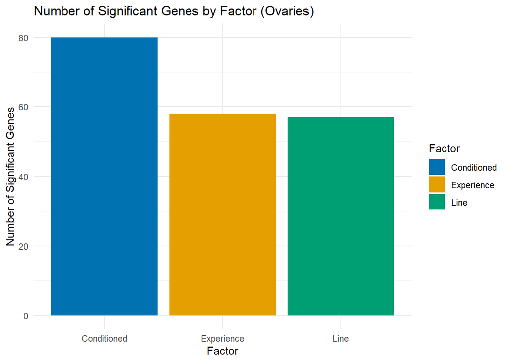

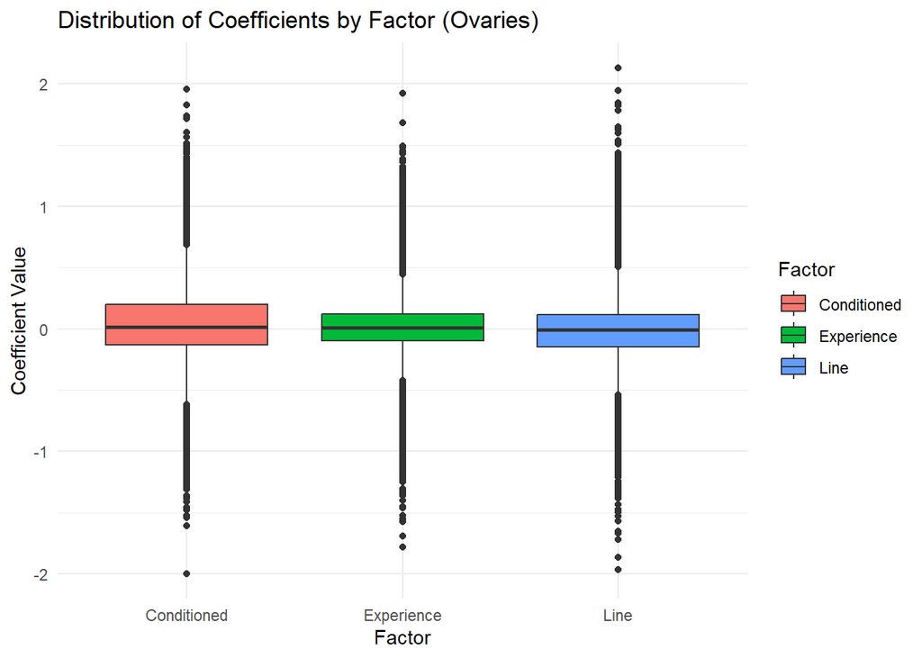

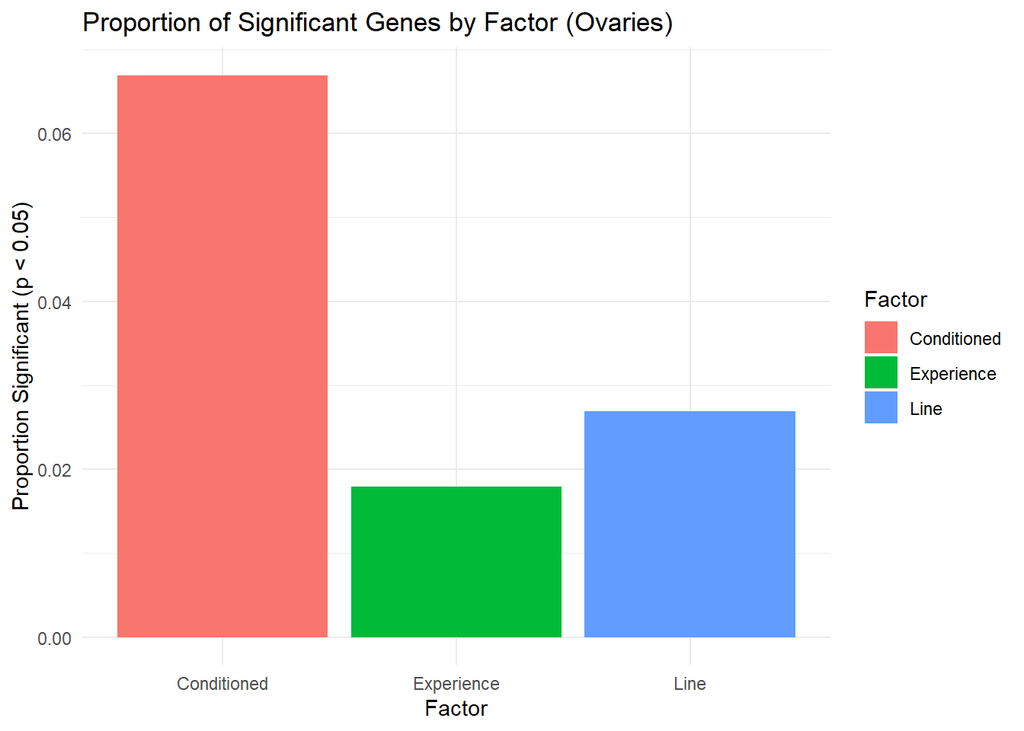

```r
      # Combine data into a long format for plotting
      ovaries_coefficients_df <- data.frame(
        Factor = rep(c("Line", "Conditioned", "Experience"), each = length(ovaries_line_coefs)),
        Coefficient = c(ovaries_line_coefs, ovaries_conditioned_coefs, ovaries_experience_coefs)
      )

      # Boxplot of coefficients to show the distribution of effects for ovaries tissue
      ggplot(ovaries_coefficients_df, aes(x = Factor, y = Coefficient, fill = Factor)) +
        geom_boxplot() +
        labs(title = "Distribution of Coefficients by Factor (Ovaries)",
             y = "Coefficient Value",
             x = "Factor") +
        theme_minimal()

      # Barplot of the proportion of significant genes for each factor in ovaries tissue
      ggplot(ovaries_summary_stats, aes(x = Factor, y = `Proportion Significant`, fill = Factor)) +
        geom_bar(stat = "identity") +
        labs(title = "Proportion of Significant Genes by Factor (Ovaries)",
             y = "Proportion Significant (p < 0.05)",
             x = "Factor") +
        theme_minimal()

#overlapping genes


    # Load your GLMM results for ovaries tissue
    fit_ovaries <- readRDS("fit_ovaries_norm.rds")

    # Extract q-values from the fit_ovaries object
    qval_results_ovaries <- glmmQvals(fit_ovaries)
##
## Line
## ----
## Not Significant     Significant
##           18105              57
##
## Conditioned
## -----------
## Not Significant     Significant
##           18082              80
##
## Experience
## ----------
## Not Significant     Significant
##           18104              58

    # Define a significance threshold for q-values
    q_threshold <- 0.05

    # Extract significant genes for each factor in ovaries
    significant_genes_line_ovaries <- rownames(qval_results_ovaries@stats$qvals)[qval_results_ovaries@stats$qvals[, "Line"] < q_threshold]
    significant_genes_conditioned_ovaries <- rownames(qval_results_ovaries@stats$qvals)[qval_results_ovaries@stats$qvals[, "Conditioned"] < q_threshold]
    significant_genes_experience_ovaries <- rownames(qval_results_ovaries@stats$qvals)[qval_results_ovaries@stats$qvals[, "Experience"] < q_threshold]

    # Calculate overlapping genes for each comparison in ovaries
    overlap_line_conditioned_ovaries <- intersect(significant_genes_line_ovaries, significant_genes_conditioned_ovaries)
    overlap_line_experience_ovaries <- intersect(significant_genes_line_ovaries, significant_genes_experience_ovaries)
    overlap_conditioned_experience_ovaries <- intersect(significant_genes_conditioned_ovaries, significant_genes_experience_ovaries)

    # Calculate overlap between all three factors (Line, Conditioned, and Experience)
    overlap_line_conditioned_experience <- Reduce(intersect, list(significant_genes_line_ovaries,
                                                                  significant_genes_conditioned_ovaries,
                                                                  significant_genes_experience_ovaries))

    # Create a data frame for the number of overlapping genes
    overlap_counts_df <- data.frame(
      Comparison = c("Line vs Conditioned",
                     "Line vs Experience",
                     "Conditioned vs Experience",
                     "Line vs Conditioned vs Experience"),
      Overlapping_Genes = c(length(overlap_line_conditioned_ovaries),
                            length(overlap_line_experience_ovaries),
                            length(overlap_conditioned_experience_ovaries),
                            length(overlap_line_conditioned_experience))
    )

    # Save the table of overlapping counts to a CSV file
    write.csv(overlap_counts_df, file = "overlapping_genes_ovaries.csv", row.names = FALSE)



    # Display the table of overlapping counts in R (formatted for R Markdown)
    kable(overlap_counts_df, caption = "Number of Overlapping Genes Between Line, Conditioned, and Experience (Ovaries)") %>%
      kable_styling(bootstrap_options = c("striped", "hover", "condensed"), full_width = F)
```

Most significant genes from Line (57 in total) and Experience (58 in total) overlap with each other (44 overlaps). The majority of Line and Conditioned genes also overlap with Conditioned: 46 for Line, 51 for Experience.

### GLMM for venom glands

Venom tissue

```r
 # Subset the data for venom tissue
      venom_samples_data <- samples_data[samples_data$Tissue == "venom", ]
      venom_counts_data <- filtered_counts_data[, rownames(venom_samples_data)]

      # Create DESeq2 object for venom tissue
      dds_venom <- DESeqDataSetFromMatrix(countData = venom_counts_data,
                                          colData = venom_samples_data,
                                          design = ~ Line + Conditioned + Experience + Family)

      # Perform DESeq normalization and dispersion estimation for venom tissue
      dds_venom <- DESeq(dds_venom)
      dispersions_venom <- dispersions(dds_venom)
      dispersions_venom <- setNames(dispersions_venom, rownames(venom_counts_data))
      size_factors_venom <- sizeFactors(dds_venom)


      # Normalize counts by size factors
      normalized_counts_venom <- sweep(venom_counts_data, 2, size_factors_venom, "/")


      # Fit the glmmSeq model for venom tissue
      #fit_venom <- glmmSeq(~ Line + Conditioned + Experience + (1 | Family),
       #                    countdata = normalized_counts_venom,
        #                   metadata = venom_samples_data,
         #                  dispersion = dispersions_venom,
          #                 family = "nbinom",
           #                progress = TRUE)

      # Save and print results for venom tissue
      #saveRDS(fit_venom, file = "fit_venom_norm.rds")
      fit_venom <- readRDS("fit_venom_norm.rds")
        #fit_venom <- readRDS("fit_venom.rds") #alternatively to the counts normalized by size factors

      results_venom <- summary(fit_venom)
      #print(results_venom)

      # Save the q-value results for venom tissue
      qval_results_venom <- glmmQvals(fit_venom)
##
## Line
## ----
## Not Significant     Significant
##           14947             160
##
## Conditioned
## -----------
## Not Significant     Significant
##           14925             182
##
## Experience
## ----------
## Not Significant     Significant
##           14974             133
```

#### model choice - venom glands

Same procedure and observation as in head and ovaries.

The files are missing on my PC for some reason, I’ll calculate the models again at some point, but the results were similar to those from head and ovaries.

#### Relative contributions of each sub-treatment to the differential gene expression - Venom glands

Same procedure as for head and ovaries.

```r
#barplots for significant genes
    # Define a significance threshold
     q_threshold <- 0.05

    # Extract the number of significant genes for each factor in venom data
      num_significant_genes_venom <- c(
       Line = sum(qval_results_venom@stats$qvals[, "Line"] < q_threshold),
        Conditioned = sum(qval_results_venom@stats$qvals[, "Conditioned"] < q_threshold),
        Experience = sum(qval_results_venom@stats$qvals[, "Experience"] < q_threshold)
            )

            # Convert to data frame for plotting
            significant_genes_venom_df <- as.data.frame(num_significant_genes_venom)
            significant_genes_venom_df$Factor <- rownames(significant_genes_venom_df)
            colnames(significant_genes_venom_df) <- c("Count", "Factor")

            # Create the bar plot using ggplot2
            library(ggplot2)
            ggplot(significant_genes_venom_df, aes(x = Factor, y = Count, fill = Factor)) +
              geom_bar(stat = "identity") +
              scale_fill_manual(values = c("#0072B2", "#E69F00", "#009E73")) +  # Colors: Blue, Orange, Green
              labs(title = "Number of Significant Genes by Factor (Venom)",
                   x = "Factor",
                   y = "Number of Significant Genes") +
              theme_minimal()

#table + plots for coefficient of each factor
    # Extract coefficients and p-values for each
     #factor by using correct indexing for venom tissue
      venom_line_coefs <- results_venom[, "LinePA"]
      venom_conditioned_coefs <- results_venom[, "ConditionedPA"]
      venom_experience_coefs <- results_venom[, "ExperiencePA"]

      venom_line_pvals <- results_venom[, "P_Line"]
      venom_conditioned_pvals <- results_venom[, "P_Conditioned"]
      venom_experience_pvals <- results_venom[, "P_Experience"]

      # Calculate summary statistics for each factor in venom tissue
      venom_summary_stats <- data.frame(
        Factor = c("Line", "Conditioned", "Experience"),
        Mean_Coefficient = c(mean(venom_line_coefs, na.rm = TRUE),
                             mean(venom_conditioned_coefs, na.rm = TRUE),
                             mean(venom_experience_coefs, na.rm = TRUE)),
        Median_Coefficient = c(median(venom_line_coefs, na.rm = TRUE),
                               median(venom_conditioned_coefs, na.rm = TRUE),
                               median(venom_experience_coefs, na.rm = TRUE)),
        Proportion_Significant = c(mean(venom_line_pvals < 0.05, na.rm = TRUE),
                                   mean(venom_conditioned_pvals < 0.05, na.rm = TRUE),
                                   mean(venom_experience_pvals < 0.05, na.rm = TRUE))
      )

      # Update the column names of venom_summary_stats for better readability
      colnames(venom_summary_stats) <- c("Factor", "Mean Coefficient", "Median Coefficient", "Proportion Significant")

      # Display the summary statistics for venom tissue using kable with updated column names
      kable(venom_summary_stats, caption = "Summary of Factor Effects on Gene Expression (Venom)") %>%
        kable_styling(bootstrap_options = c("striped", "hover", "condensed"), full_width = F)
```

Summary of Factor Effects on Gene Expression (Venom)

| Factor | Mean Coefficient | Median Coefficient | Proportion Significant |
| --- | --- | --- | --- |
| Line | 0.1493367 | 0.1158974 | 0.0415701 |
| Conditioned | 0.0682307 | 0.0733727 | 0.0689746 |
| Experience | 0.0156137 | 0.0093325 | 0.0223737 |

Number of Overlapping Genes Between Line, Conditioned, and Experience (Venom)

| Comparison | Overlapping_Genes |
| --- | --- |
| Line vs Conditioned | 128 |
| Line vs Experience | 123 |
| Conditioned vs Experience | 114 |
| Line vs Conditioned vs Experience | 106 |

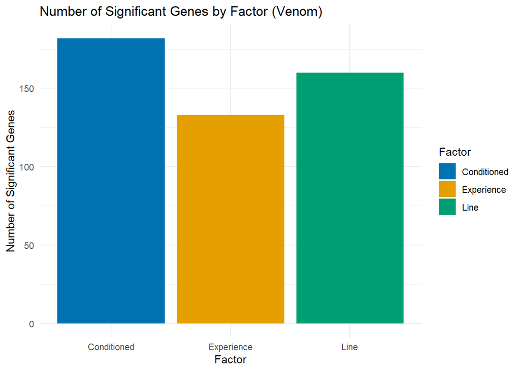

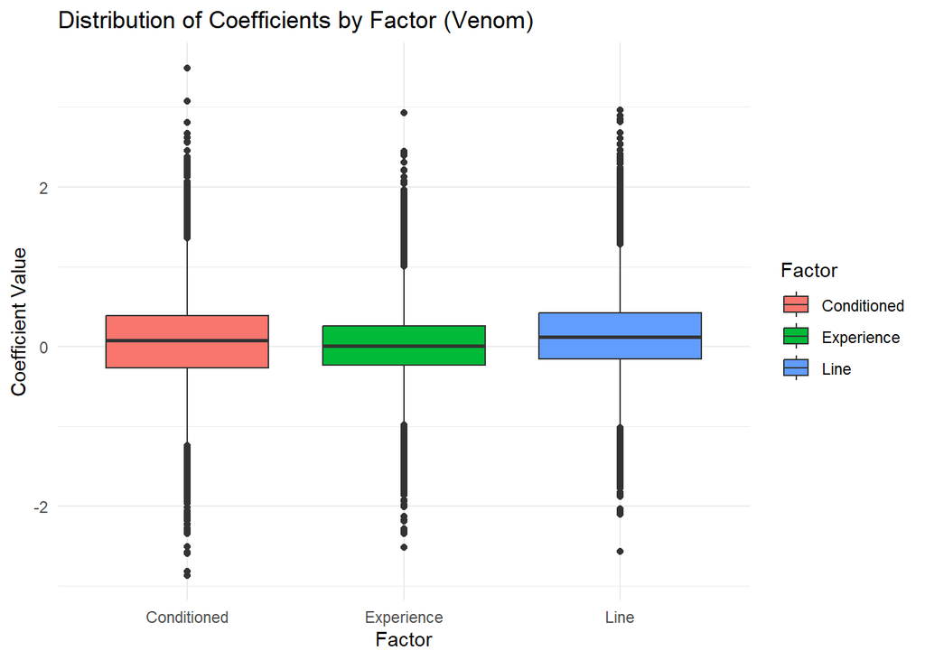

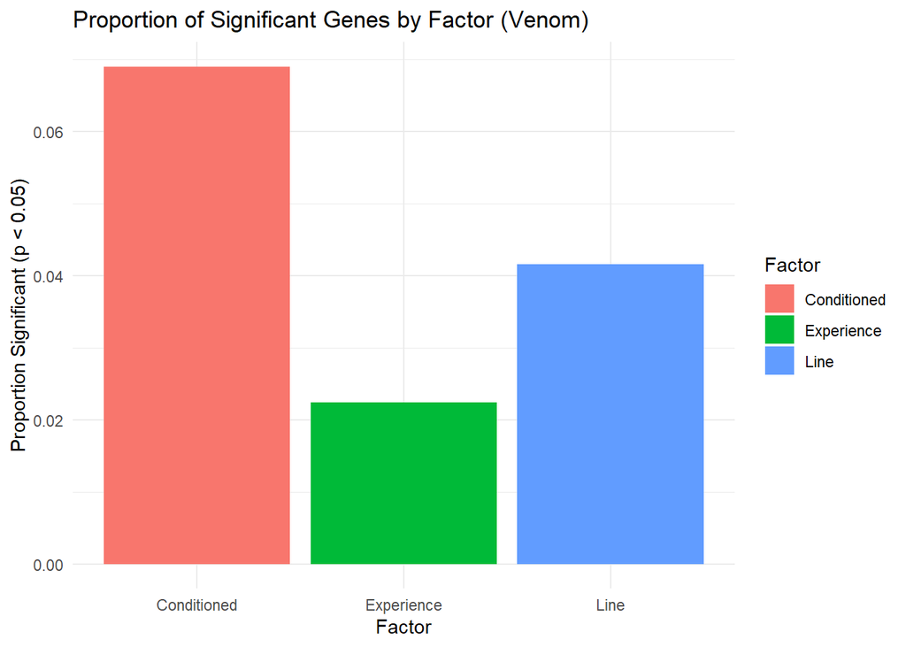

```r
      # Combine data into a long format for plotting
      venom_coefficients_df <- data.frame(
        Factor = rep(c("Line", "Conditioned", "Experience"), each = length(venom_line_coefs)),
        Coefficient = c(venom_line_coefs, venom_conditioned_coefs, venom_experience_coefs)
      )

      # Boxplot of coefficients to show the distribution of effects for venom tissue
      ggplot(venom_coefficients_df, aes(x = Factor, y = Coefficient, fill = Factor)) +
        geom_boxplot() +
        labs(title = "Distribution of Coefficients by Factor (Venom)",
             y = "Coefficient Value",
             x = "Factor") +
        theme_minimal()

      # Barplot of the proportion of significant genes for each factor in venom tissue
      ggplot(venom_summary_stats, aes(x = Factor, y = `Proportion Significant`, fill = Factor)) +
        geom_bar(stat = "identity") +
        labs(title = "Proportion of Significant Genes by Factor (Venom)",
             y = "Proportion Significant (p < 0.05)",
             x = "Factor") +
        theme_minimal()

#overlapping genes

    # Load your GLMM results for venom tissue
    fit_venom <- readRDS("fit_venom_norm.rds")

    # Extract q-values from the fit_venom object
    qval_results_venom <- glmmQvals(fit_venom)
##
## Line
## ----
## Not Significant     Significant
##           14947             160
##
## Conditioned
## -----------
## Not Significant     Significant
##           14925             182
##
## Experience
## ----------
## Not Significant     Significant
##           14974             133

    # Define a significance threshold for q-values
    q_threshold <- 0.05

    # Extract significant genes for each factor in venom tissue
    significant_genes_line_venom <- rownames(qval_results_venom@stats$qvals)[qval_results_venom@stats$qvals[, "Line"] < q_threshold]
    significant_genes_conditioned_venom <- rownames(qval_results_venom@stats$qvals)[qval_results_venom@stats$qvals[, "Conditioned"] < q_threshold]
    significant_genes_experience_venom <- rownames(qval_results_venom@stats$qvals)[qval_results_venom@stats$qvals[, "Experience"] < q_threshold]

    # Calculate overlapping genes for each comparison in venom tissue
    overlap_line_conditioned_venom <- intersect(significant_genes_line_venom, significant_genes_conditioned_venom)
    overlap_line_experience_venom <- intersect(significant_genes_line_venom, significant_genes_experience_venom)
    overlap_conditioned_experience_venom <- intersect(significant_genes_conditioned_venom, significant_genes_experience_venom)

    # Calculate overlap between all three factors (Line, Conditioned, and Experience) for venom tissue
    overlap_line_conditioned_experience_venom <- Reduce(intersect, list(significant_genes_line_venom,
                                                                        significant_genes_conditioned_venom,
                                                                        significant_genes_experience_venom))

    # Create a data frame for the number of overlapping genes in venom tissue
    overlap_counts_df_venom <- data.frame(
      Comparison = c("Line vs Conditioned",
                     "Line vs Experience",
                     "Conditioned vs Experience",
                     "Line vs Conditioned vs Experience"),
      Overlapping_Genes = c(length(overlap_line_conditioned_venom),
                            length(overlap_line_experience_venom),
                            length(overlap_conditioned_experience_venom),
                            length(overlap_line_conditioned_experience_venom))
    )

    # Save the table of overlapping counts to a CSV file for venom tissue
    write.csv(overlap_counts_df_venom, file = "overlapping_genes_venom.csv", row.names = FALSE)

    # Display the table of overlapping counts in R (formatted for R Markdown)
    kable(overlap_counts_df_venom, caption = "Number of Overlapping Genes Between Line, Conditioned, and Experience (Venom)") %>%
      kable_styling(bootstrap_options = c("striped", "hover", "condensed"), full_width = F)
```

Again, the majority of significant genes of each sub-treatment overlap with each other. Also, the number of significant genes from experience is higher than in all remaining tissues, implying a higher relevance of the host encounter for venom gland transcriptome than for other tissues.

Similarly to head, Conditioned has by far the highest number of significant genes in proportion to the total number of genes analyzed by the model, Experience the lowest.

## Overlapping genes between tissue types

```r
# Load the GLMM results for each tissue
fit_head <- readRDS("fit_head_norm.rds")
fit_ovaries <- readRDS("fit_ovaries_norm.rds")
fit_venom <- readRDS("fit_venom_norm.rds")

# Extract q-values for each tissue
qval_results_head <- glmmQvals(fit_head)
##
## Line
## ----
## Not Significant     Significant
##           17472             186
##
## Conditioned
## -----------
## Not Significant     Significant
##           16754             904
##
## Experience
## ----------
## Not Significant     Significant
##           17620              38
qval_results_ovaries <- glmmQvals(fit_ovaries)
##
## Line
## ----
## Not Significant     Significant
##           18105              57
##
## Conditioned
## -----------
## Not Significant     Significant
##           18082              80
##
## Experience
## ----------
## Not Significant     Significant
##           18104              58
qval_results_venom <- glmmQvals(fit_venom)
##
## Line
## ----
## Not Significant     Significant
##           14947             160
##
## Conditioned
## -----------
## Not Significant     Significant
##           14925             182
##
## Experience
## ----------
## Not Significant     Significant
##           14974             133

# Define significance threshold
q_threshold <- 0.05

# Extract significant genes for each tissue type
significant_genes_head <- rownames(qval_results_head@stats$qvals)[qval_results_head@stats$qvals[, "Line"] < q_threshold]
significant_genes_ovaries <- rownames(qval_results_ovaries@stats$qvals)[qval_results_ovaries@stats$qvals[, "Line"] < q_threshold]
significant_genes_venom <- rownames(qval_results_venom@stats$qvals)[qval_results_venom@stats$qvals[, "Line"] < q_threshold]

# Calculate the pairwise overlaps between tissue types
overlap_head_ovaries <- intersect(significant_genes_head, significant_genes_ovaries)
overlap_head_venom <- intersect(significant_genes_head, significant_genes_venom)
overlap_ovaries_venom <- intersect(significant_genes_ovaries, significant_genes_venom)

# Calculate the overlap between all three tissue types
overlap_all_tissues <- Reduce(intersect, list(significant_genes_head, significant_genes_ovaries, significant_genes_venom))

# Create a data frame to show the overlap counts
overlap_counts_df <- data.frame(
  Comparison = c("Head vs Ovaries", "Head vs Venom", "Ovaries vs Venom", "All Tissues"),
  Overlapping_Genes = c(length(overlap_head_ovaries),
                        length(overlap_head_venom),
                        length(overlap_ovaries_venom),
                        length(overlap_all_tissues))
)

# Print the table in R Markdown using kable
kable(overlap_counts_df, caption = "Number of Overlapping Genes Between Tissue Types") %>%
  kable_styling(bootstrap_options = c("striped", "hover", "condensed"), full_width = F)
```

Number of Overlapping Genes Between Tissue Types

| Comparison | Overlapping_Genes |
| --- | --- |
| Head vs Ovaries | 1 |
| Head vs Venom | 4 |
| Ovaries vs Venom | 3 |
| All Tissues | 0 |

AS shown in the preliminary results from the PCA, there are no overlapping genes between all tissue types, and only few in pairwise comparisons of the tissue types.

## Volcano plots for significant genes from the models

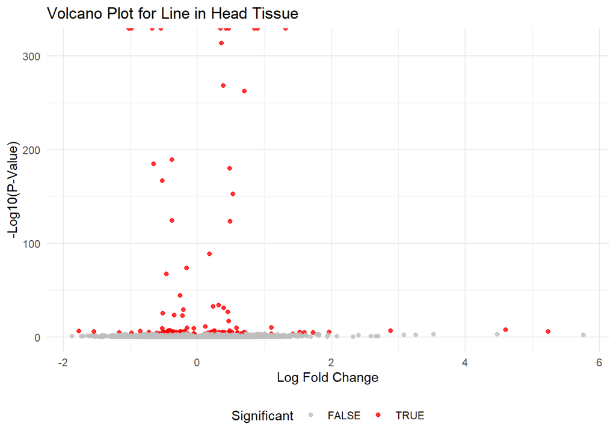

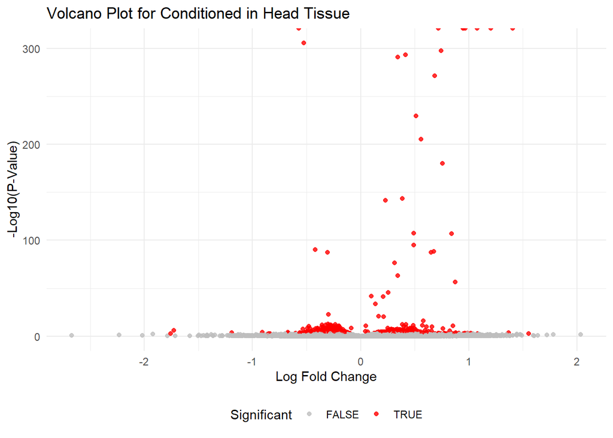

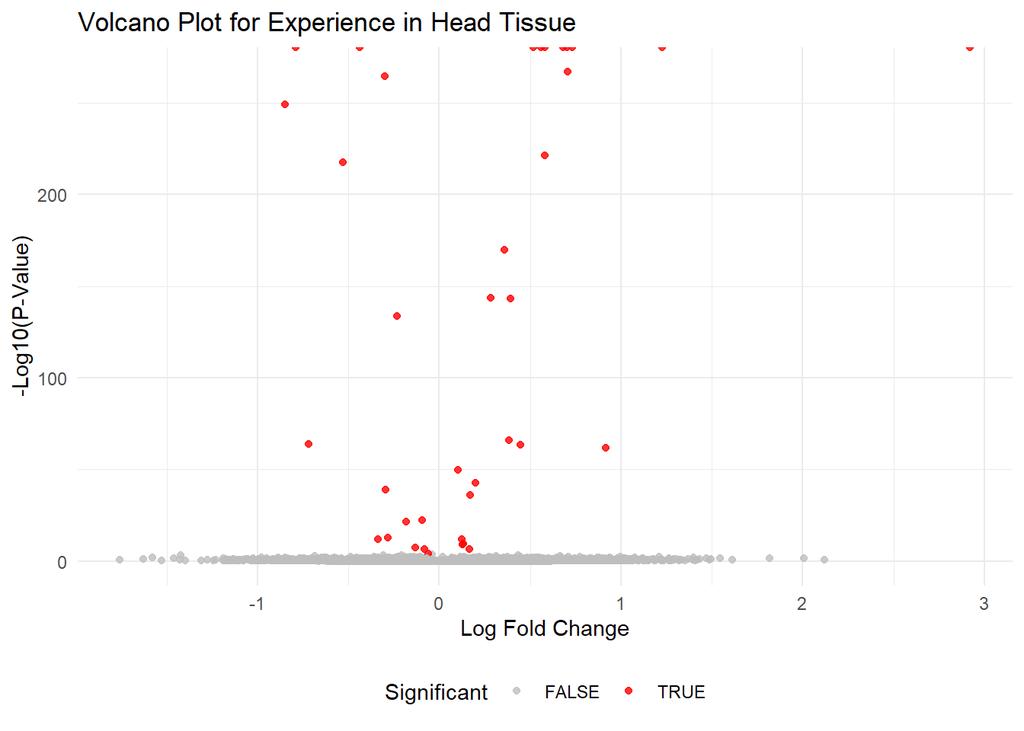

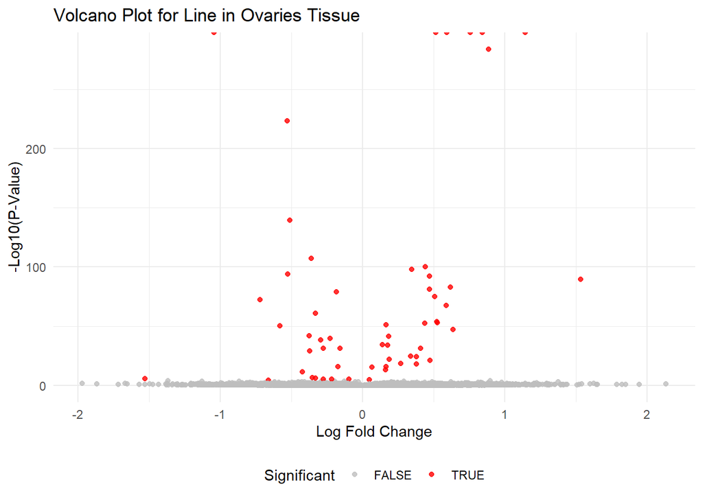

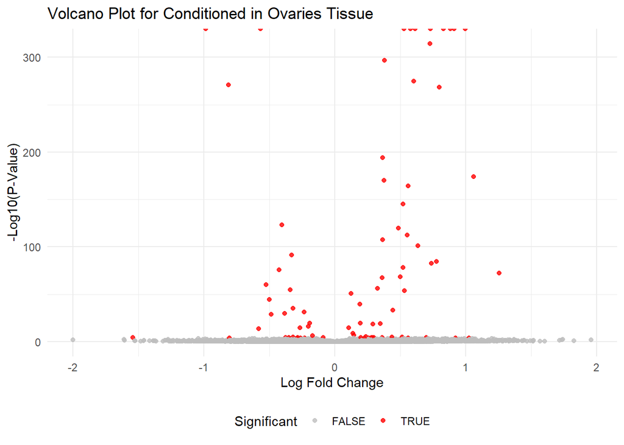

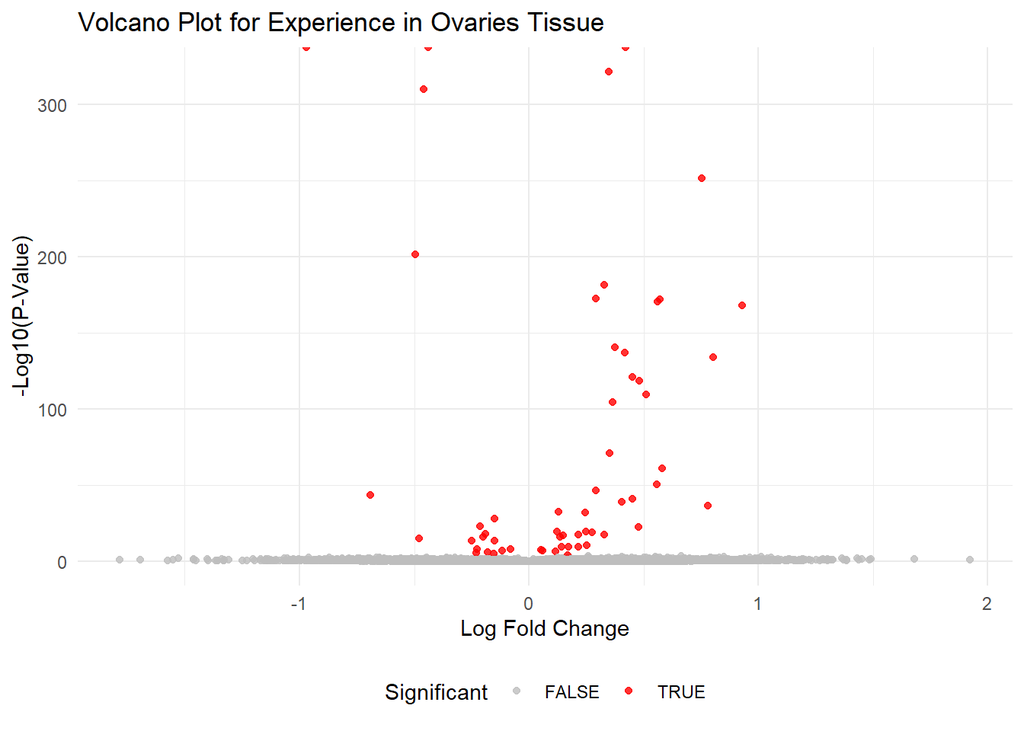

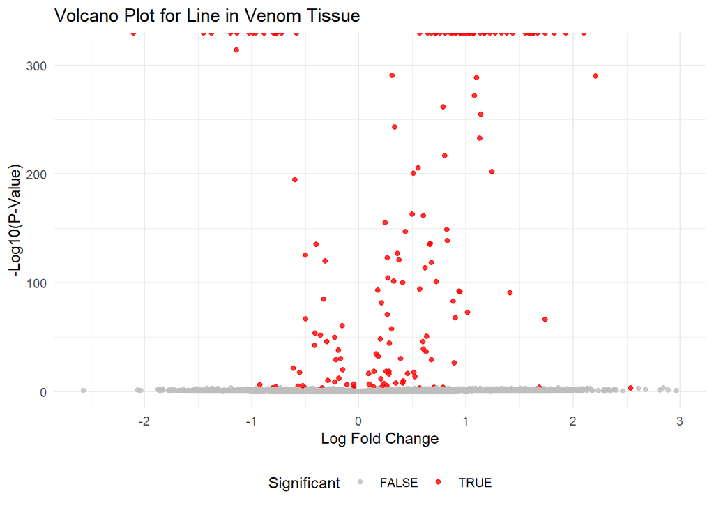

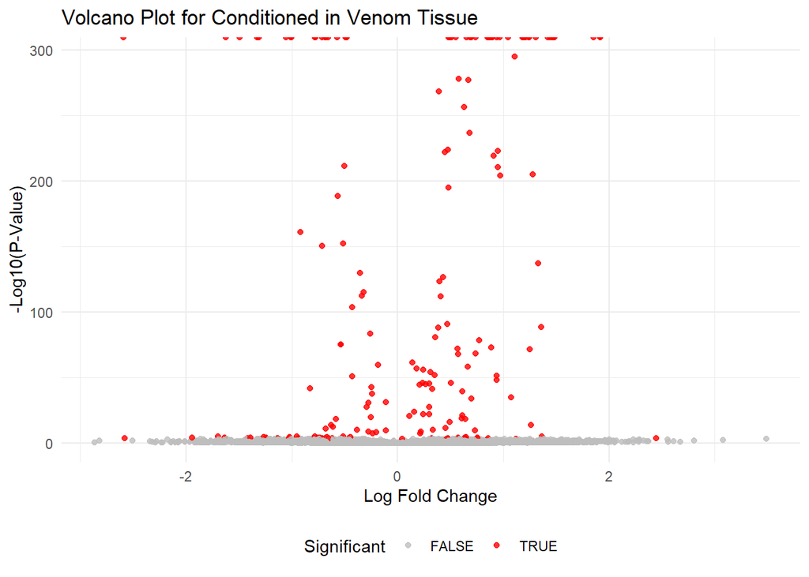

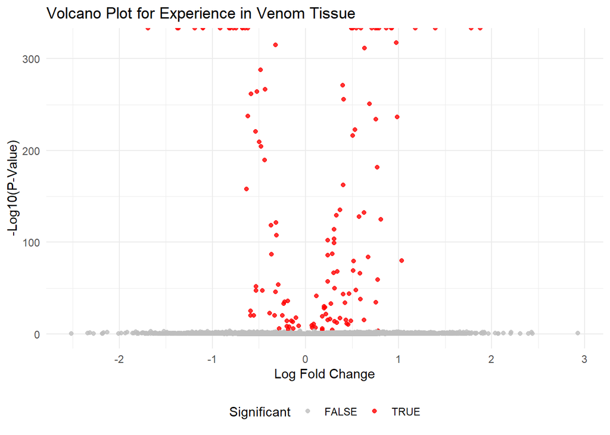

```r
# Function to extract significant genes from glmmSeq results
extract_significant_genes <- function(glmm_model, factor_name, q_threshold = 0.05) {
  qvals <- glmmQvals(glmm_model)
  significant_genes <- rownames(qvals@stats$qvals)[qvals@stats$qvals[, factor_name] < q_threshold]
  return(significant_genes)
}

# Function to create volcano plots
create_volcano_plot <- function(glmm_model, factor_name, tissue_type) {
  results <- summary(glmm_model)
  df <- data.frame(
    Gene = rownames(results),
    logFC = results[, paste0(factor_name, "PA")],
    pvalue = results[, paste0("P_", factor_name)]
  )
  df$adj_pvalue <- p.adjust(df$pvalue, method = "fdr")
  df$Significant <- df$adj_pvalue < 0.05

  ggplot(df, aes(x = logFC, y = -log10(pvalue), color = Significant)) +
    geom_point(alpha = 0.8) +
    scale_color_manual(values = c("grey", "red")) +
    labs(title = paste("Volcano Plot for", factor_name, "in", tissue_type),
         x = "Log Fold Change",
         y = "-Log10(P-Value)") +
    theme_minimal() +
    theme(legend.position = "bottom")
}

# Load GLMM models for each tissue type
# Assuming these files exist and have been saved as .RDS files
head1 <- readRDS("fit_head_norm.rds")
ovaries1 <- readRDS("fit_ovaries_norm.rds")
venom1 <- readRDS("fit_venom_norm.rds")

# Generate volcano plots for each tissue type and each factor (Line, Conditioned, Experience)

# Head Tissue
volcano_plot_head_line <- create_volcano_plot(head1, "Line", "Head Tissue")
volcano_plot_head_conditioned <- create_volcano_plot(head1, "Conditioned", "Head Tissue")
volcano_plot_head_experience <- create_volcano_plot(head1, "Experience", "Head Tissue")

# Ovaries Tissue
volcano_plot_ovaries_line <- create_volcano_plot(ovaries1, "Line", "Ovaries Tissue")
volcano_plot_ovaries_conditioned <- create_volcano_plot(ovaries1, "Conditioned", "Ovaries Tissue")
volcano_plot_ovaries_experience <- create_volcano_plot(ovaries1, "Experience", "Ovaries Tissue")

# Venom Tissue
volcano_plot_venom_line <- create_volcano_plot(venom1, "Line", "Venom Tissue")
volcano_plot_venom_conditioned <- create_volcano_plot(venom1, "Conditioned", "Venom Tissue")
volcano_plot_venom_experience <- create_volcano_plot(venom1, "Experience", "Venom Tissue")

# Display the plots
print(volcano_plot_head_line)
print(volcano_plot_head_conditioned)
print(volcano_plot_head_experience)

print(volcano_plot_ovaries_line)
print(volcano_plot_ovaries_conditioned)
print(volcano_plot_ovaries_experience)

print(volcano_plot_venom_line)
print(volcano_plot_venom_conditioned)
print(volcano_plot_venom_experience)
```

Check which side stands for PA/FA

```r
# If Line, Conditioned, and Experience are not factors, convert them to factors
samples_data$Line <- factor(samples_data$Line)
samples_data$Conditioned <- factor(samples_data$Conditioned)
samples_data$Experience <- factor(samples_data$Experience)

# Confirm the levels of each factor
levels(samples_data$Line)
## [1] "FA" "PA"
levels(samples_data$Conditioned)
## [1] "FA" "PA"
levels(samples_data$Experience)
## [1] "FA" "PA"
```

Extract dataframes to save significant genes (q < 0.05) as csv. The coefficient column represents the logfold change from the corresponding GLMM. Genes with positive values are upregulated, genes with negative values downregulated.

The QValue column represents the adj. p-values. These values were adjusted for multiple testing by using the Benjamini-Hochberg method.

```r
#head
    # Extract q-values, coefficients, standard errors, and p-values from the GlmmSeq object
                #Line
                    # Obtain the q-values, coefficients, etc., for the head tissue
                    qvals_matrix_head <- qval_results_head@stats$qvals
                    coef_matrix_head <- qval_results_head@stats$coef
                    stderr_matrix_head <- qval_results_head@stats$stdErr
                    pvals_matrix_head <- qval_results_head@stats$pvals


                    # Set the significance threshold
                    q_threshold <- 0.05

                    # For the Line factor (head tissue)
                    sig_genes_line_head <- rownames(qvals_matrix_head)[qvals_matrix_head[, "Line"] < q_threshold]

                    # Create the data frame for Line using "LinePA" in coef_matrix and stderr_matrix
                    head_line_df <- data.frame(
                      Gene = sig_genes_line_head,
                      Coefficient = coef_matrix_head[sig_genes_line_head, "LinePA"],
                      StdError = stderr_matrix_head[sig_genes_line_head, "LinePA"],
                      PValue = pvals_matrix_head[sig_genes_line_head, "Line"],
                      QValue = qvals_matrix_head[sig_genes_line_head, "Line"]
                    )

                #Conditioned

                    # For the Conditioned factor (head tissue)
                    sig_genes_conditioned_head <- rownames(qvals_matrix_head)[qvals_matrix_head[, "Conditioned"] < q_threshold]

                    # Create the data frame for Conditioned using "ConditionedPA" in coef_matrix and stderr_matrix
                    head_conditioned_df <- data.frame(
                      Gene = sig_genes_conditioned_head,
                      Coefficient = coef_matrix_head[sig_genes_conditioned_head, "ConditionedPA"],
                      StdError = stderr_matrix_head[sig_genes_conditioned_head, "ConditionedPA"],
                      PValue = pvals_matrix_head[sig_genes_conditioned_head, "Conditioned"],
                      QValue = qvals_matrix_head[sig_genes_conditioned_head, "Conditioned"]
                    )

                #Experience

                    # For the Experience factor (head tissue)
                    sig_genes_experience_head <- rownames(qvals_matrix_head)[qvals_matrix_head[, "Experience"] < q_threshold]

                    # Create the data frame for Experience using "ExperiencePA" in coef_matrix and stderr_matrix
                    head_experience_df <- data.frame(
                      Gene = sig_genes_experience_head,
                      Coefficient = coef_matrix_head[sig_genes_experience_head, "ExperiencePA"],
                      StdError = stderr_matrix_head[sig_genes_experience_head, "ExperiencePA"],
                      PValue = pvals_matrix_head[sig_genes_experience_head, "Experience"],
                      QValue = qvals_matrix_head[sig_genes_experience_head, "Experience"]
                    )

              #save CSVs
                    write.csv(head_line_df, file = "head_line.csv", row.names = FALSE)
                    write.csv(head_conditioned_df, file = "head_conditioned.csv", row.names = FALSE)
                    write.csv(head_experience_df, file = "head_experience.csv", row.names = FALSE)


#ovaries
   # Extract q-values, coefficients, standard errors, and p-values from the GlmmSeq object
            # Obtain the q-values, coefficients, etc., for the ovaries tissue
            qval_results_ovaries <- glmmQvals(fit_ovaries)
##
## Line
## ----
## Not Significant     Significant
##           18105              57
##
## Conditioned
## -----------
## Not Significant     Significant
##           18082              80
##
## Experience
## ----------
## Not Significant     Significant
##           18104              58
            qvals_matrix_ovaries <- qval_results_ovaries@stats$qvals
            coef_matrix_ovaries <- qval_results_ovaries@stats$coef
            stderr_matrix_ovaries <- qval_results_ovaries@stats$stdErr
            pvals_matrix_ovaries <- qval_results_ovaries@stats$pvals

            # Set the significance threshold
            q_threshold <- 0.05

              #Line
                    sig_genes_line_ovaries <- rownames(qvals_matrix_ovaries)[qvals_matrix_ovaries[, "Line"] < q_threshold]

                    # Create the data frame for Line using "LinePA" in coef_matrix and stderr_matrix
                    ovaries_line_df <- data.frame(
                      Gene = sig_genes_line_ovaries,
                      Coefficient = coef_matrix_ovaries[sig_genes_line_ovaries, "LinePA"],
                      StdError = stderr_matrix_ovaries[sig_genes_line_ovaries, "LinePA"],
                      PValue = pvals_matrix_ovaries[sig_genes_line_ovaries, "Line"],
                      QValue = qvals_matrix_ovaries[sig_genes_line_ovaries, "Line"]
                    )

              #Conditioned
                    sig_genes_conditioned_ovaries <- rownames(qvals_matrix_ovaries)[qvals_matrix_ovaries[, "Conditioned"] < q_threshold]

                    # Create the data frame for Conditioned using "ConditionedPA" in coef_matrix and stderr_matrix
                    ovaries_conditioned_df <- data.frame(
                      Gene = sig_genes_conditioned_ovaries,
                      Coefficient = coef_matrix_ovaries[sig_genes_conditioned_ovaries, "ConditionedPA"],
                      StdError = stderr_matrix_ovaries[sig_genes_conditioned_ovaries, "ConditionedPA"],
                      PValue = pvals_matrix_ovaries[sig_genes_conditioned_ovaries, "Conditioned"],
                      QValue = qvals_matrix_ovaries[sig_genes_conditioned_ovaries, "Conditioned"]
                    )

              #Experience

                    # For the Experience factor (ovaries tissue)
                    sig_genes_experience_ovaries <- rownames(qvals_matrix_ovaries)[qvals_matrix_ovaries[, "Experience"] < q_threshold]

                    # Create the data frame for Experience using "ExperiencePA" in coef_matrix and stderr_matrix
                    ovaries_experience_df <- data.frame(
                      Gene = sig_genes_experience_ovaries,
                      Coefficient = coef_matrix_ovaries[sig_genes_experience_ovaries, "ExperiencePA"],
                      StdError = stderr_matrix_ovaries[sig_genes_experience_ovaries, "ExperiencePA"],
                      PValue = pvals_matrix_ovaries[sig_genes_experience_ovaries, "Experience"],
                      QValue = qvals_matrix_ovaries[sig_genes_experience_ovaries, "Experience"]
                    )

              #save CSVs
                    write.csv(ovaries_line_df, file = "ovaries_line.csv", row.names = FALSE)
                    write.csv(ovaries_conditioned_df, file = "ovaries_conditioned.csv", row.names = FALSE)
                    write.csv(ovaries_experience_df, file = "ovaries_experience.csv", row.names = FALSE)

#venom
      # Extract q-values, coefficients, standard errors, and p-values from the GlmmSeq object
      qvals_matrix <- qval_results_venom@stats$qvals
      coef_matrix <- qval_results_venom@stats$coef
      stderr_matrix <- qval_results_venom@stats$stdErr
      pvals_matrix <- qval_results_venom@stats$pvals

      # Set the significance threshold
      q_threshold <- 0.05

      # For the Line factor
      sig_genes_line <- rownames(qvals_matrix)[qvals_matrix[, "Line"] < q_threshold]

            # Create the data frame for Line using "LinePA" in coef_matrix and stderr_matrix
              venom_line_df <- data.frame(
              Gene = sig_genes_line,
              Coefficient = coef_matrix[sig_genes_line, "LinePA"],
              StdError = stderr_matrix[sig_genes_line, "LinePA"],
              PValue = pvals_matrix[sig_genes_line, "Line"],
              QValue = qvals_matrix[sig_genes_line, "Line"]
            )


      # For the Conditioned factor
      sig_genes_conditioned <- rownames(qvals_matrix)[qvals_matrix[, "Conditioned"] < q_threshold]

            # Create the data frame for Conditioned using "ConditionedPA" in coef_matrix and stderr_matrix
              venom_conditioned_df <- data.frame(
              Gene = sig_genes_conditioned,
              Coefficient = coef_matrix[sig_genes_conditioned, "ConditionedPA"],
              StdError = stderr_matrix[sig_genes_conditioned, "ConditionedPA"],
              PValue = pvals_matrix[sig_genes_conditioned, "Conditioned"],
              QValue = qvals_matrix[sig_genes_conditioned, "Conditioned"]
            )


      # For the Experience factor
      sig_genes_experience <- rownames(qvals_matrix)[qvals_matrix[, "Experience"] < q_threshold]

            # Create the data frame for Experience using "ExperiencePA" in coef_matrix and stderr_matrix
              venom_experience_df <- data.frame(
              Gene = sig_genes_experience,
              Coefficient = coef_matrix[sig_genes_experience, "ExperiencePA"],
              StdError = stderr_matrix[sig_genes_experience, "ExperiencePA"],
              PValue = pvals_matrix[sig_genes_experience, "Experience"],
              QValue = qvals_matrix[sig_genes_experience, "Experience"]
            )


          #save CSVs
                  #write.csv(venom_line_df, file = "venom_line.csv", row.names = FALSE)
                  #write.csv(venom_conditioned_df, file = "venom_conditioned.csv", row.names = FALSE)
                  #write.csv(venom_experience_df, file = "venom_experience.csv", row.names = FALSE)
```

## To do list

Remaining objectives:

- attempt to utilize the GLMM results to create heatmaps for treatment similarity based on the GLMM data.
- GO enrichment analysis with the sets of genes from the GLMMs
- morpological quantification using phenopype
- write Thesis and hand in